# **1. Overview | Warehouse Robot | Deterministic and Stochastic Environment**

In part 1, I define a tiny warehouse world for a robot. The robot lives on a 6×6 grid with shelves as obstacles. Its job is simple: start somewhere, pick up an item from a fixed pickup cell, and deliver it to a fixed drop-off cell while avoiding shelves and staying within bounds. The setup follows the Gymnasium style environment interface with `reset`, `step`, and `render`.

I implement two versions of the same environment:

1. A deterministic version where actions do exactly what they say (no randomness), and
2. A stochastic version where movements can slip with a small probability (so the same action may lead to different results).

Then I sanity check both by running a random agent for ≥10 steps, printing the state, action, reward each step, and rendering the grid so I can visually verify the logic.

# **2. Imports**

```python
import gymnasium
from gymnasium import spaces
import math
import matplotlib.pyplot as plt
import numpy as np
import pandas as pd
import random
```

# **3. Environment Configuration**

- We fix the environment to a 6×6 grid as required.
- We need a few shelves (obstacles) that block movement.
- The robot has a start position.
- There’s a single pickup cell and a single drop-off cell.
- Rewards follow the assignment spec:
  - +100 for delivery
  - +25 for first pick-up
  - −1 per step
  - −20 for hitting an obstacle

The episode ends when the robot successfully delivers the item.

```python
# Configuration for the Warehouse Robot environment
class WarehouseConfig:
    n_rows = 6
    n_cols = 6

    # Obstacle layout
    shelves = [(1,2),(1,3),(2,3),(3,3),(4,1),(4,2)]

    # Key positions
    start = (0,0)
    pickup = (0,5)
    dropoff = (5,5)

    # Rewards
    step_penalty = -1
    obstacle_penalty = -20
    pickup_reward = +25
    deliver_reward = +100

    # to randomize start and the goal locations
    randomize_start  = False
    randomize_goals  = False
```

# **4. Helper Functions**

**4.1 Bounds check**

This helper function makes sure the robot never steps outside the grid. It treats the grid as the only valid world and rejects any move that tries to go beyond the edges. The function checks both the row and column index. If both are valid, it returns `True`, otherwise it returns `False`. In technical terms, it outputs a **Boolean value** (`bool`). We will call this inside `step()` whenever the robot attempts a movement, so the agent always remains inside the defined state space.

```python
def in_bounds(r, c, n_rows, n_cols):
    """
    Input:
        r (int) - row index
        c (int) - column index
        n_rows (int) - number of rows in the grid
        n_cols (int) - number of columns in the grid
    Output:
        bool - True if (r, c) lies inside the grid, False otherwise
    """
    return 0 <= r < n_rows and 0 <= c < n_cols
```

**4.2 Shelf collision check**

This helper function tells us whether a target cell is a shelf. It compares the cell coordinates to the list of shelves and returns `True` if the cell is in the shelf list, otherwise `False`. The output is again a **Boolean value** (`bool`). If a move would land on a shelf, we will block the move and later apply the obstacle penalty. This is part of our safety measures because the robot is not allowed to pass through shelves.

```python
def is_shelf(cell, shelves):
    """
    Input:
        cell (tuple) - a position (row, col)
        shelves (list of tuples) - positions of shelves
    Output:
        bool - True if the cell is a shelf, False otherwise
    """
    return tuple(cell) in shelves
```

**4.3 Observation encoder**

This helper function returns the minimal observation we use for this environment. The observation consists of the robot’s row, the robot’s column, and a flag that says whether the robot is carrying the item : (`row, col, carrying_flag`). The `carrying_flag` is `0` if the robot is not carrying an item and `1` if it is. The output type is a tuple of integers (`tuple`). We will call this in both `reset()` and `step()` so the agent always receives the same consistent state format.

```python
def encode_obs(r, c, carrying):
    """
    Input:
        r (int) - row index
        c (int) - column index
        carrying (bool) - whether the robot is carrying an item
    Output:
        tuple - (row, col, carrying_flag) where carrying_flag is 0 or 1
    """
    return (r, c, int(carrying))
```

**4.4 Observation index (for part 2)**

This helper function converts the observation tuple (`row, col, carry`) into a single integer index. This is useful in Part 2 when building a Q-table, it can directly use the index as the key in an array. The output is an integer (`int`).

```python
def obs_to_index(obs, n_rows, n_cols):
    """
    Input:
        obs (tuple) - (row, col, carry)
        n_rows (int) - number of rows in the grid
        n_cols (int) - number of columns in the grid
    Output:
        int - index value in [0, 2 * n_rows * n_cols - 1]
    """
    r, c, carry = obs
    return carry * (n_rows * n_cols) + r * n_cols + c
```

# **5. Base Environment Class**

This section sets up the main environment class that follows the Gymnasium standards. As per the given instructions every environment must have four key methods: `__init__`, `reset`, `step`, and `render`. Here we build a base version with `__init__`, `reset`, and `render`. We leave `step` empty so that we can fill it later for deterministic vs stochastic environments.

## **`__init__`**

This method is called when we first create the environment. It defines the action space (six possible actions: up, down, left, right, pick-up, drop-off) and the observation space (row, column, carrying flag). It also stores the grid size, shelves, and reward values.

## **`reset`**

This method resets the environment at the start of an episode. It places the robot at the start cell, clears the carrying flag, and sets everything back to initial values. It returns the first observation and an empty info dictionary.

## **`step`**

This is the method that executes one action. We don’t implement it here in the base class because we need two different versions later (deterministic and stochastic). In this base class, we only declare it and raise an error if someone tries to call it.

## **`render`**

This method prints a simple grid to the screen. It shows shelves as `[ # ]`, pickup `[P]`, drop-off `[D]`, and the agent as `[A]` if empty-handed or `[a]` if carrying an item.

We also expose two optional toggles via reset(). This satisfies “The robot should be able to navigate from any start position to any target position” without changing default behavior.

```python
import gymnasium as gym
from gymnasium import spaces

# Movement actions (row, col) deltas
# 0: UP, 1: DOWN, 2: LEFT, 3: RIGHT, 4: PICK, 5: DROP
MOVE_ACTIONS = {0: (-1, 0), 1: (1, 0), 2: (0, -1), 3: (0, 1)}
PICK, DROP = 4, 5
N_ACTIONS = 6

class WarehouseBase(gym.Env):
    """
    Base class: sets spaces, seeding, reset, and a simple ASCII render.
    Subclasses implement step() logic (deterministic vs stochastic).
    """
    metadata = {"render_modes": ["ansi"]}

    def __init__(self, cfg):
        super().__init__()
        self.cfg = cfg

        # Spaces:

        # observation=(row, col, carry_flag)
        self.observation_space = spaces.Tuple((
            spaces.Discrete(cfg.n_rows),
            spaces.Discrete(cfg.n_cols),
            spaces.Discrete(2)
        ))

        # action in {0..5}
        self.action_space = spaces.Discrete(N_ACTIONS)

        # Cache layout
        self.n_rows = cfg.n_rows
        self.n_cols = cfg.n_cols
        self.shelves = [tuple(x) for x in cfg.shelves]
        self.start = tuple(cfg.start)
        self.pickup = tuple(cfg.pickup)
        self.dropoff = tuple(cfg.dropoff)

        # Rewards
        self.step_penalty      = cfg.step_penalty
        self.obstacle_penalty  = cfg.obstacle_penalty
        self.pickup_reward     = cfg.pickup_reward
        self.deliver_reward    = cfg.deliver_reward

        # Episode state
        self.r = None
        self.c = None
        self.carrying = False
        self.picked_once = False

        # Safety assertions
        assert self.start not in self.shelves,   "start cannot be on a shelf"
        assert self.pickup not in self.shelves,  "pickup cannot be on a shelf"
        assert self.dropoff not in self.shelves, "dropoff cannot be on a shelf"
        assert self.pickup != self.dropoff,      "pickup and dropoff must differ"

    def reset(self, seed=None, options=None):
        """
        Reset episode state to the configured start cell and clear flags.
        """
        super().reset(seed=seed)
        if seed is not None:
            import random
            np.random.seed(seed)
            random.seed(seed)

        # Random goal locations (distinct, free cells)
        if getattr(self.cfg, "randomize_goals", False):
            free = [(r, c) for r in range(self.n_rows) for c in range(self.n_cols)
                      if (r, c) not in self.shelves]
            self.pickup = random.choice(free)
            free2 = [xy for xy in free if xy != self.pickup]
            self.dropoff = random.choice(free2)

        # Random starting locations (free and not pick/drop)
        if getattr(self.cfg, "randomize_start", False):
            free = [(r, c) for r in range(self.n_rows) for c in range(self.n_cols)
                      if (r, c) not in self.shelves and (r, c) != self.pickup and (r, c) != self.dropoff]
            self.r, self.c = random.choice(free)
        else:
            self.r, self.c = self.start

        self.carrying = False
        self.picked_once = False

        obs = encode_obs(self.r, self.c, self.carrying)
        info = {}
        return obs, info

    def step(self, action):
        """
        Subclasses implement this.
        """
        raise NotImplementedError

    def render(self):
        """
        ASCII grid:
          [#] shelf, [P] pickup, [D] dropoff,
          [A] agent (empty), [a] agent (carrying), [. ] empty.
        """
        # Draw from top row to bottom row
        lines = []
        for rr in range(self.n_rows):
            row_cells = []
            for cc in range(self.n_cols):
                ch = "."
                if (rr, cc) in self.shelves:
                    ch = "#"
                elif (rr, cc) == self.pickup:
                    ch = "P"
                elif (rr, cc) == self.dropoff:
                    ch = "D"
                if (rr, cc) == (self.r, self.c):
                    ch = "a" if self.carrying else "A"
                row_cells.append(f"[{ch}]")
            lines.append(" ".join(row_cells))
        # Print with top row first (row 0 at the top)
        print("\n".join(lines))
        print(f"pos=({self.r},{self.c}) carrying={self.carrying}")
```

# **6. Deterministic Environment (`WarehouseDeterministicEnv`)**

In this section we implement the `step()` method for a deterministic MDP. Every action produces a fixed, predictable outcome: moves change the position by exactly one cell (unless blocked), `Pick-up` picks the item only at the pickup cell, and Drop-off delivers only at the `drop-off` cell. Each step applies the step penalty, collisions with shelves add the obstacle penalty, the first successful pick-up adds the pickup reward, and a successful delivery adds the deliver reward and ends the episode. We always return (`observation, reward, terminated, truncated, info`).

Logic we’ll implement inside `step(action)`

- Start with `reward = step_penalty` every time.
- If the action is a **move** (Up/Down/Left/Right):
  - compute the tentative next cell
  - If the tentative next cell is out of bounds, it stays in place (stay inside grid)
  - if the next cell is a shelf, **do not move** and add `obstacle_penalty`
  - otherwise update `(r, c)` to the next cell
- If the action is **Pick-up**:
  - if at `pickup` and not carrying, set `carrying=True` and award `pickup_reward` **only the first time**
  - otherwise do nothing extra (one of the safety policy)
- If the action is **Drop-off**:
  - if at `dropoff` and carrying, award `deliver_reward`, set `terminated=True`, and set `carrying=False`
  - otherwise do nothing extra
- Build the new observation with `encode_obs(r, c, carrying)` and return it with flags.

```python
class WarehouseDeterministicEnv(WarehouseBase):

    def step(self, action):
        reward = self.step_penalty
        terminated = False
        truncated = False
        blocked_oob = False # bloccked because the movement is out-of-bound
        blocked_shelf = False # blocked because the movement is into a shelf

        if action in MOVE_ACTIONS:
            dr, dc = MOVE_ACTIONS[action]
            nr, nc = self.r + dr, self.c + dc

            # bounds: reject illegal move (stay in place)
            if not in_bounds(nr, nc, self.n_rows, self.n_cols):
                blocked_oob = True
                nr, nc = self.r, self.c  # stay put

            # shelves: block and penalize (only if not out-of-bound)
            elif is_shelf((nr, nc), self.shelves):
                blocked_shelf = True
                reward += self.obstacle_penalty
                nr, nc = self.r, self.c  # stay put
            else:
                self.r, self.c = nr, nc

        elif action == PICK:
            if (self.r, self.c) == self.pickup and not self.carrying:
                self.carrying = True
                if not self.picked_once:
                    reward += self.pickup_reward
                    self.picked_once = True
            # else: silent, no operation (safety policy)

        elif action == DROP:
            if self.carrying and (self.r, self.c) == self.dropoff:
                reward += self.deliver_reward
                self.carrying = False
                terminated = True
            # else: silent, no operation

        obs = encode_obs(self.r, self.c, self.carrying)
        info = {"blocked_oob": blocked_oob, "blocked_shelf": blocked_shelf}
        return obs, reward, terminated, truncated, info
```

# **7. Stochastic Environment (`WarehouseStochasticEnv`)**

This section implements `step()` for a stochastic MDP. The only difference from the deterministic version is that movement can fail with a small probability. We model this as a slip: when the agent issues a move action (up/down/left/right), the move succeeds with probability `p` and the agent stays in place with probability `1 - p`. This makes the transition probabilistic while keeping the environment simple and safe. Pick-up and drop-off remain deterministic because the randomness is only in movement.

- We add a constructor argument `move_success_p` (default `0.9`), so we can tune the amount of randomness.
- On every step we still apply the step penalty.
- If a move succeeds, we do the same bounds and shelf checks as in Section 6.
- If a move slips, the agent stays at the current cell for that step.
- Pick-up and drop-off logic is identical to the deterministic environment.

```python
import random

class WarehouseStochasticEnv(WarehouseBase):
    def __init__(self, cfg, move_success_p=0.9):
        super().__init__(cfg)
        self.move_success_p = move_success_p
        self._rng = random.Random()  # Random Number Generator (RNG) scoped to this local environment instance

    def reset(self, seed=None, options=None):
        # seed env-local RNG + parent reset to seed spaces
        if seed is not None:
            self._rng.seed(seed)
        return super().reset(seed=seed, options=options)

    def step(self, action):
        reward = self.step_penalty
        terminated = False
        truncated = False
        slipped = False
        blocked_oob = False
        blocked_shelf = False

        if action in MOVE_ACTIONS:
            # decide success vs slip with env-local RNG
            if self._rng.random() < self.move_success_p:
                dr, dc = MOVE_ACTIONS[action]
                nr, nc = self.r + dr, self.c + dc

                # bounds: reject illegal move (stay put)
                if not in_bounds(nr, nc, self.n_rows, self.n_cols):
                    blocked_oob = True
                    nr, nc = self.r, self.c

                # shelves: block and penalize
                elif is_shelf((nr, nc), self.shelves):
                    blocked_shelf = True
                    reward += self.obstacle_penalty
                    nr, nc = self.r, self.c
                else:
                    self.r, self.c = nr, nc
            else:
                slipped = True  # stayed in place

        elif action == PICK:
            if (self.r, self.c) == self.pickup and not self.carrying:
                self.carrying = True
                if not self.picked_once:
                    reward += self.pickup_reward
                    self.picked_once = True

        elif action == DROP:
            if self.carrying and (self.r, self.c) == self.dropoff:
                reward += self.deliver_reward
                self.carrying = False
                terminated = True

        obs = encode_obs(self.r, self.c, self.carrying)
        info = {"move_success_p": self.move_success_p,
                "slipped": slipped,
                "blocked_oob": blocked_oob,
                "blocked_shelf": blocked_shelf}
        return obs, reward, terminated, truncated, info
```

- The parameter `move_success_p` is the probability of success for a movement action. When it is 0.9, the agent moves as intended 90% of the time and slips (stays in place) 10% of the time.
- The probability mass for each move action is split between “success → deterministic transition” and “slip → stay put,” so the transition probabilities sum to 1.
- We keep pick-up and drop-off deterministic because this task only needs a stochastic twist, making movement stochastic is the simplest and clearest choice.
- Safety is unchanged: out-of-bounds moves are clipped to the grid, shelves block motion and add the obstacle penalty.

# **8. Random rollout helper**

This helper runs a short episode with a random policy. It resets the environment, then for a fixed number of steps it samples a random action from the action space, calls `step(action)`, prints the state, action, reward, and calls `render()` each step so we can visually verify the behavior.

```python
def run_random_episode(env, max_steps=15, seed=1227, verbose=True):
    # seed once; env handles its own RNG + spaces
    res = env.reset(seed=seed)
    if isinstance(res, tuple) and len(res) == 2:
        obs, info = res
    else:
        obs, info = res, {}

    total = 0.0

    if verbose:
        print("---- RESET ----")
        print("obs:", obs, "obs_idx:", obs_to_index(obs, env.n_rows, env.n_cols))
        env.render()

    for t in range(max_steps):
        a = env.action_space.sample()
        obs, r, term, trunc, info = env.step(a)
        total += r

        if verbose:
            a_name = {0:"UP",1:"DOWN",2:"LEFT",3:"RIGHT",4:"PICK",5:"DROP"}[a]
            print(
                f"t={t:02d} action={a}({a_name}) obs={obs} "
                f"obs_idx={obs_to_index(obs, env.n_rows, env.n_cols)} "
                f"reward={r:.1f} total={total:.1f} term={term} "
                f"{'slip' if info.get('slipped') else ''}"
                f"{' oob'  if info.get('blocked_oob') else ''}"
                f"{' shelf' if info.get('blocked_shelf') else ''}"
            )
            env.render()

        if term or trunc:
            if verbose:
                print("Episode terminated.")
            break

    return total
```

- We set `max_steps=15` by default to satisfy the “≥10 steps” requirement.
- The random agent uses `env.action_space.sample()` so it exercises all actions over time (move, pick, drop).
- We print after each step and render the grid.

# **9. Demo runs (deterministic + stochastic)**

Now we instantiate both environments using the configuration from Section 3, and run the random rollout helper on each.

**Deterministic Env**

```python
print("=== Deterministic Environment ===")
cfg = WarehouseConfig()
det_env = WarehouseDeterministicEnv(cfg)
det_return = run_random_episode(det_env, max_steps=15, seed=1227, verbose=True)
print("Deterministic episode total return:", det_return)
```

```
=== Deterministic Environment ===
---- RESET ----
obs: (0, 0, 0) obs_idx: 0
[A] [.] [.] [.] [.] [P]
[.] [.] [#] [#] [.] [.]
[.] [.] [.] [#] [.] [.]
[.] [.] [.] [#] [.] [.]
[.] [#] [#] [.] [.] [.]
[.] [.] [.] [.] [.] [D]
pos=(0,0) carrying=False
t=00 action=5(DROP) obs=(0, 0, 0) obs_idx=0 reward=-1.0 total=-1.0 term=False
[A] [.] [.] [.] [.] [P]
[.] [.] [#] [#] [.] [.]
[.] [.] [.] [#] [.] [.]
[.] [.] [.] [#] [.] [.]
[.] [#] [#] [.] [.] [.]
[.] [.] [.] [.] [.] [D]
pos=(0,0) carrying=False
t=01 action=2(LEFT) obs=(0, 0, 0) obs_idx=0 reward=-1.0 total=-2.0 term=False  oob
[A] [.] [.] [.] [.] [P]
[.] [.] [#] [#] [.] [.]
[.] [.] [.] [#] [.] [.]
[.] [.] [.] [#] [.] [.]
[.] [#] [#] [.] [.] [.]
[.] [.] [.] [.] [.] [D]
pos=(0,0) carrying=False
t=02 action=3(RIGHT) obs=(0, 1, 0) obs_idx=1 reward=-1.0 total=-3.0 term=False
[.] [A] [.] [.] [.] [P]
[.] [.] [#] [#] [.] [.]
[.] [.] [.] [#] [.] [.]
[.] [.] [.] [#] [.] [.]
[.] [#] [#] [.] [.] [.]
[.] [.] [.] [.] [.] [D]
pos=(0,1) carrying=False
t=03 action=4(PICK) obs=(0, 1, 0) obs_idx=1 reward=-1.0 total=-4.0 term=False
[.] [A] [.] [.] [.] [P]
[.] [.] [#] [#] [.] [.]
[.] [.] [.] [#] [.] [.]
[.] [.] [.] [#] [.] [.]
[.] [#] [#] [.] [.] [.]
```

[output cut: 76 more lines]

```
[.] [.] [#] [#] [.] [.]
[.] [.] [.] [#] [.] [.]
[.] [.] [.] [#] [.] [.]
[.] [#] [#] [.] [.] [.]
[.] [.] [.] [.] [.] [D]
pos=(0,0) carrying=False
t=14 action=1(DOWN) obs=(1, 0, 0) obs_idx=6 reward=-1.0 total=-15.0 term=False
[.] [.] [.] [.] [.] [P]
[A] [.] [#] [#] [.] [.]
[.] [.] [.] [#] [.] [.]
[.] [.] [.] [#] [.] [.]
[.] [#] [#] [.] [.] [.]
[.] [.] [.] [.] [.] [D]
pos=(1,0) carrying=False
Deterministic episode total return: -15.0
```

**Stochastic**

```python
print("\n=== Stochastic Environment (p=0.9) ===")
sto_env = WarehouseStochasticEnv(cfg, move_success_p=0.9)
sto_return = run_random_episode(sto_env, max_steps=15, seed=1227, verbose=True)
print("Stochastic episode total return:", sto_return)
```

```
=== Stochastic Environment (p=0.9) ===
---- RESET ----
obs: (0, 0, 0) obs_idx: 0
[A] [.] [.] [.] [.] [P]
[.] [.] [#] [#] [.] [.]
[.] [.] [.] [#] [.] [.]
[.] [.] [.] [#] [.] [.]
[.] [#] [#] [.] [.] [.]
[.] [.] [.] [.] [.] [D]
pos=(0,0) carrying=False
t=00 action=1(DOWN) obs=(1, 0, 0) obs_idx=6 reward=-1.0 total=-1.0 term=False
[.] [.] [.] [.] [.] [P]
[A] [.] [#] [#] [.] [.]
[.] [.] [.] [#] [.] [.]
[.] [.] [.] [#] [.] [.]
[.] [#] [#] [.] [.] [.]
[.] [.] [.] [.] [.] [D]
pos=(1,0) carrying=False
t=01 action=5(DROP) obs=(1, 0, 0) obs_idx=6 reward=-1.0 total=-2.0 term=False
[.] [.] [.] [.] [.] [P]
[A] [.] [#] [#] [.] [.]
[.] [.] [.] [#] [.] [.]
[.] [.] [.] [#] [.] [.]
[.] [#] [#] [.] [.] [.]
[.] [.] [.] [.] [.] [D]
pos=(1,0) carrying=False
t=02 action=1(DOWN) obs=(2, 0, 0) obs_idx=12 reward=-1.0 total=-3.0 term=False
[.] [.] [.] [.] [.] [P]
[.] [.] [#] [#] [.] [.]
[A] [.] [.] [#] [.] [.]
[.] [.] [.] [#] [.] [.]
[.] [#] [#] [.] [.] [.]
[.] [.] [.] [.] [.] [D]
pos=(2,0) carrying=False
t=03 action=5(DROP) obs=(2, 0, 0) obs_idx=12 reward=-1.0 total=-4.0 term=False
[.] [.] [.] [.] [.] [P]
[.] [.] [#] [#] [.] [.]
[A] [.] [.] [#] [.] [.]
[.] [.] [.] [#] [.] [.]
[.] [#] [#] [.] [.] [.]
```

[output cut: 76 more lines]

```
[.] [.] [#] [#] [.] [.]
[.] [.] [A] [#] [.] [.]
[.] [.] [.] [#] [.] [.]
[.] [#] [#] [.] [.] [.]
[.] [.] [.] [.] [.] [D]
pos=(2,2) carrying=False
t=14 action=1(DOWN) obs=(3, 2, 0) obs_idx=20 reward=-1.0 total=-35.0 term=False
[.] [.] [.] [.] [.] [P]
[.] [.] [#] [#] [.] [.]
[.] [.] [.] [#] [.] [.]
[.] [.] [A] [#] [.] [.]
[.] [#] [#] [.] [.] [.]
[.] [.] [.] [.] [.] [D]
pos=(3,2) carrying=False
Stochastic episode total return: -35.0
```

# **10. Safety & Reproducibility Checks**

Here we run a small safety test on both environments to confirm the core invariants hold. I seed the env for reproducibility, reset once, and step up to a small number of random actions while asserting that the agent

- always stays within bounds and
- never stands on a shelf.

I break early if the episode terminates. If no assertion fails, the function returns "ok". Therefore, seeing `det: ok` and `sto: ok` tells me the deterministic and stochastic variants both satisfy these safety checks.

```python
def safety_smoke_test(env, steps=25, seed=1227):
    obs, _ = env.reset(seed=seed)
    for _ in range(steps):
        # agent never leaves grid or stands on a shelf
        assert 0 <= env.r < env.n_rows and 0 <= env.c < env.n_cols
        assert (env.r, env.c) not in env.shelves
        a = env.action_space.sample()
        obs, r, term, trunc, _ = env.step(a)
        if term or trunc:
            break
    return "ok"

cfg = WarehouseConfig()
print("det:", safety_smoke_test(WarehouseDeterministicEnv(cfg)))
print("sto:", safety_smoke_test(WarehouseStochasticEnv(cfg, move_success_p=0.9)))
```

```
det: ok
sto: ok
```

# **11. Visualizations of the environment**

```python
import matplotlib.pyplot as plt
from matplotlib.patches import Rectangle

def save_env_snapshot(env, filename, title=None):
    """
    Save a simple image of the current grid state.
    Cells:
      shelves = gray, pickup = green, dropoff = blue, empty = white
    Agent: dot at current cell; '*' overlay if carrying.
    """
    n_rows, n_cols = env.n_rows, env.n_cols

    fig, ax = plt.subplots(figsize=(n_cols * 0.6, n_rows * 0.6))
    ax.set_xlim(-0.5, n_cols - 0.5)
    ax.set_ylim(-0.5, n_rows - 0.5)
    ax.set_aspect("equal")

    # draw cells (flip vertically so row 0 is at the top, matching our ASCII)
    for r in range(n_rows):
        for c in range(n_cols):
            face = "white"
            if (r, c) in env.shelves:
                face = "#b0b4ba"     # shelf (gray)
            if (r, c) == env.pickup:
                face = "#b9e7a1"     # pickup (green-ish)
            if (r, c) == env.dropoff:
                face = "#a1c6f0"     # dropoff (blue-ish)

            # place rectangle with row flip (y = n_rows - 1 - r)
            rr = n_rows - 1 - r
            rect = Rectangle((c - 0.5, rr - 0.5), 1, 1,
                             edgecolor="black", facecolor=face, linewidth=0.6)
            ax.add_patch(rect)

    # agent
    ar, ac = env.r, env.c
    ay = n_rows - 1 - ar
    ax.plot(ac, ay, marker="o", markersize=10)
    if env.carrying:
        ax.text(ac, ay, "*", ha="center", va="center", fontsize=10, weight="bold")

    # grid cosmetics
    ax.set_xticks(range(n_cols))
    ax.set_yticks(range(n_rows))
    ax.grid(True, linewidth=0.5)
    if title:
        ax.set_title(title)
    plt.tight_layout()
    plt.savefig(filename, dpi=150)
    plt.close(fig)

# Create a few representative snapshots
cfg = WarehouseConfig()

# Deterministic: reset + mid-episode
det_env = WarehouseDeterministicEnv(cfg)
det_env.reset(seed=11)
save_env_snapshot(det_env, "snap_det_reset.png", "Deterministic — reset")

# take a couple of RIGHT steps for a mid-episode snapshot
det_env.step(3)  # RIGHT
det_env.step(3)  # RIGHT
save_env_snapshot(det_env, "snap_det_mid.png", "Deterministic — mid")

# Stochastic: reset
sto_env = WarehouseStochasticEnv(cfg, move_success_p=0.9)
sto_env.reset(seed=11)
save_env_snapshot(sto_env, "snap_sto_reset.png", "Stochastic — reset")

print("Saved: snap_det_reset.png, snap_det_mid.png, snap_sto_reset.png")
```

```
Saved: snap_det_reset.png, snap_det_mid.png, snap_sto_reset.png
```

# **1. Overview | Tabular RL on the Warehouse Robot (Deterministic & Stochastic)**

In this section I train tabular agents to solve the same 6×6 warehouse world defined in Part 1. The robot must start at the configured start cell, pick up the item at (0,5), and deliver it to (5,5) while avoiding shelves and staying within bounds. The action set and rewards are unchanged

I implement two tabular control methods:

- **Q-learning** (off-policy TD control) as the baseline.
- **SARSA** (on-policy TD control) as the comparison method

Both algorithms are trained and evaluated on both environment variants:

- Deterministic: actions move as commanded unless blocked by bounds or shelves.
- Stochastic: movement succeeds with probability `move_success_p=0.9`, otherwise the agent slips (stays in place). PICK and DROP remain deterministic.

I also run a hyperparameter study. I vary two hyperparameters (e.g., discount factor γ and epsilon decay) across three values each, keep all other settings fixed during each sweep, and re-run the full evaluation bundle for each setting. Then, we could recommend a configuration based on learning stability, final greedy performance, and robustness to stochastic movement.

# **2. State, Action, and Table Representation (for Tabular Methods)**

**State format.** I keep the exact observation from Part 1: a tuple `(row, col, carrying_flag)`. The flag is `0` when the robot is empty-handed and `1` after the first successful pickup. This is the minimal state needed to know where the robot is and whether DROP would be meaningful.

**State indexing.** For tabular learning I convert each observation to a unique integer using the same `obs_to_index` convention from Part 1. With a 6×6 grid and two carry states, the total number of states is `2 × 6 × 6 = 72`. All tables will therefore be indexed in `[0 … 71]`, so training and evaluation remain consistent across environments.

**Action set.** The action space is unchanged and fixed at 6 actions:

- `UP, DOWN, LEFT, RIGHT` for movement,
- `PICK` to pick up the item (only works at the pickup cell when not already carrying),
- `DROP` to deliver the item (only works at the drop-off cell when carrying).

Out-of-bounds moves are clipped to “stay in place.” Moves into shelves are blocked and penalized (step penalty plus obstacle penalty). `PICK`/`DROP` outside their valid cells are safe no-ops (only the step penalty applies). These rules match Part 1 exactly.

**Rewards and termination.** Each step incurs `−1`. The first successful pickup grants `+25` once per episode. Attempting to move into a shelf adds `−20`. A successful delivery gives `+100` and terminates the episode. I continue to use separate `terminated` vs `truncated` flags: we expect `terminated=True` only on successful delivery; `truncated` would remain `False` unless I explicitly set a time limit per episode.

**Tables.** Both algorithms (Q-learning and SARSA) use a tabular action-value function `Q` with shape `(num_states, 6) = (72, 6)`. I will save:

- an initial snapshot of the untrained table,
- the final trained table after learning on each environment,
- and a serialized artifact (e.g., `.pkl`) per run for reuse and reproducibility.

**Exploration and evaluation policies.** Training uses ε-greedy (decaying ε). All evaluation is strictly greedy (ε=0) so the reported returns reflect the learned policy, not exploration noise.

# **3. Experiment Protocol & Reproducibility**

This section fixes how I will run, log, and evaluate every experiment in Part 2 so results are consistent and repeatable.

**Environments and parameters**

- Deterministic: `WarehouseDeterministicEnv(cfg)`
- Stochastic: `WarehouseStochasticEnv(cfg, move_success_p=0.9)`
- Grid, shelves, start, pickup, dropoff, and rewards are exactly the same as in Part 1.
- `randomize_start=False`, `randomize_goals=False` during training/evaluation unless a robustness check explicitly says otherwise.

**Episode budget and time limits.**

- Training episodes: 2,000 per run (adjustable; chosen to allow stable learning on 6×6).
- Per-episode max steps: 200 (keeps runs finite even if the agent wanders and successful delivery terminates earlier).
- Evaluation uses the same step cap but usually finishes earlier upon delivery.

**Exploration and schedules.**

- ε-greedy during training with:
  - `epsilon_start = 1.0`, `epsilon_min = 0.05`, multiplicative `epsilon_decay = 0.995`.
- Evaluation is strictly greedy (`ε = 0`).

**Learning rates and discount.**

- Default Q/SARSA training: `alpha = 0.1`, `gamma = 0.99`.
- These serve as the baseline, the hyperparameter study (later) will vary `gamma` and `epsilon_decay` across predefined grids.

**Logging per episode (for all runs).**

- `total_reward` (learning curve).
- `epsilon` (exploration schedule).

**Evaluation protocol (for every trained table).**

- 10 greedy episodes per environment–algorithm pair; report:
  - episode returns (plotted),
  - mean ± std return (printed in a tiny summary).
- 1 greedy showcase episode with `render()` at each step and a brief caption.

# **4. Q-Learning (Implementation & Training)**

Here I implement tabular **Q-learning** and train it on both environments from Part 1 (deterministic and stochastic).

- Initializes a zero Q-table with shape `(num_states, 6)`.
- Trains with ε-greedy exploration (multiplicative decay).
- Logs total reward per episode and epsilon per episode.
- Saves the untrained and trained Q-tables as artifacts.
- Produces learning-curve plots (rewards vs. episodes) and epsilon-schedule plots.
- Prints a concise summary (final average of the last N episodes).

**4.1 Helpers: table init, ε-greedy, directory utils, and plotting**

```python
import os, pickle
import numpy as np
import matplotlib.pyplot as plt

# Ensure reproducibility for algorithm-level randomness (separate from env RNG).
ALG_SEED = 1227
_alg_rng = np.random.default_rng(ALG_SEED)

def ensure_dir(path):
    os.makedirs(path, exist_ok=True)

def num_states_from_env(env):
    # Uses the known structure: (row, col, carry_flag)
    return 2 * env.n_rows * env.n_cols

def init_q_table(env):
    nS = num_states_from_env(env)
    nA = env.action_space.n
    Q = np.zeros((nS, nA), dtype=float)
    return Q

def epsilon_greedy(Q, s_idx, epsilon):
    # Sample random action with probability epsilon; otherwise greedy.
    if _alg_rng.random() < epsilon:
        return _alg_rng.integers(Q.shape[1])
    return int(np.argmax(Q[s_idx]))

def plot_series(y, title, xlabel, ylabel, outpath=None, show=True):
    plt.figure(figsize=(6.5,4.0))
    plt.plot(y)
    plt.title(title)
    plt.xlabel(xlabel)
    plt.ylabel(ylabel)
    plt.tight_layout()
    if outpath:
        ensure_dir(os.path.dirname(outpath))
        plt.savefig(outpath, dpi=300)
        if show:
            plt.show()
        plt.close()
    else:
        if show:
            plt.show()
```

**4.2 Training loop for Q-learning**

- Input: environment, training hyperparameters, and step cap.
- Logic: standard Q-learning update $$ Q(s, a) \leftarrow Q(s, a) + \alpha \left( r + \gamma \cdot \max_{a'} Q(s', a') - Q(s, a) \right) $$
- Output: trained Q, reward history, epsilon history.

```python
def train_q_learning(
    env,
    episodes=2000,
    max_steps=200,
    alpha=0.10,
    gamma=0.99,
    epsilon_start=1.0,
    epsilon_min=0.05,
    epsilon_decay=0.995,
    seed=1227,
):
    """
    Train tabular Q-learning on the given env.
    Returns:
        Q             : (num_states, n_actions) array
        rewards_hist  : list[float], total reward per episode
        eps_hist      : list[float], epsilon value per episode
    """
    Q = init_q_table(env)
    rewards_hist, eps_hist = [], []

    epsilon = float(epsilon_start)

    for ep in range(episodes):
        # Seed env per episode for reproducibility of starts/stochasticity
        obs, _ = env.reset(seed=seed)
        s = obs_to_index(obs, env.n_rows, env.n_cols)

        done = False
        total = 0.0

        for t in range(max_steps):
            a = epsilon_greedy(Q, s, epsilon)
            obs2, r, terminated, truncated, _ = env.step(a)
            s2 = obs_to_index(obs2, env.n_rows, env.n_cols)
            done = terminated or truncated

            # Q-learning TD target
            best_next = 0.0 if done else np.max(Q[s2])
            td_target = r + gamma * best_next
            td_error  = td_target - Q[s, a]
            Q[s, a]  += alpha * td_error

            s = s2
            total += r
            if done:
                break

        rewards_hist.append(total)
        eps_hist.append(epsilon)
        epsilon = max(epsilon_min, epsilon * epsilon_decay)

    return Q, rewards_hist, eps_hist
```

**4.3 Baseline hyperparameters (documented here for traceability)**

- Episodes: 2000
- Max steps per episode: 200
- α (learning rate): 0.10
- γ (discount): 0.99
- Exploration: ε-greedy with `ε₀ = 1.0` → `ε_min = 0.05`, multiplicative `ε_decay = 0.995`
- Seeds: environment resets and algorithm RNG both seeded with 1227

**4.4 Training runs (Deterministic & Stochastic), saving artifacts, and plotting**

This cell:

- Instantiates both envs from Part 1 (same config).
- Saves untrained Q-tables for traceability.
- Trains Q-learning on each env with the baseline hyperparameters.
- Saves the trained Q-tables as `.pkl`.
- Plots and saves learning curves (rewards) and epsilon curves.

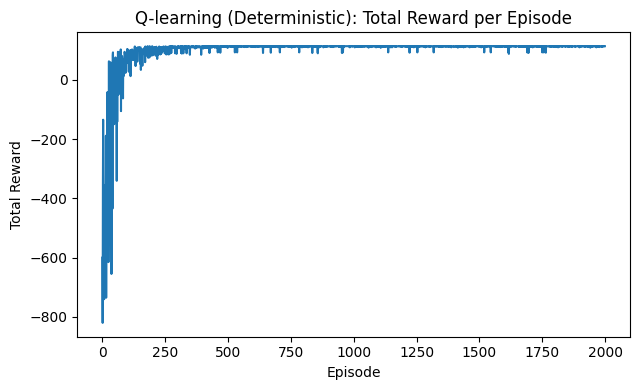

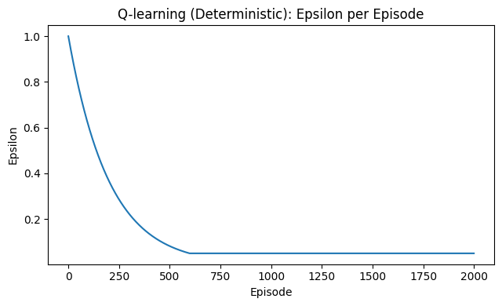

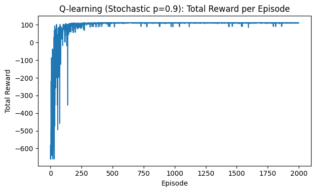

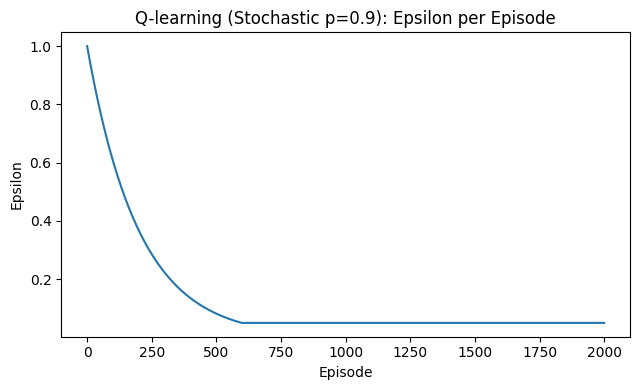

```
[Q-learning] Deterministic — last 100 eps: mean=112.43, std=0.97
[Q-learning] Stochastic (p=0.9) — last 100 eps: mean=111.25, std=0.99
Saved artifacts: artifacts/qlearning_det_untrained.pkl, artifacts/qlearning_sto_untrained.pkl, artifacts/qlearning_det.pkl, artifacts/qlearning_sto.pkl
Saved plots: plots/det_qlearn_rewards.png, plots/det_qlearn_epsilon.png, plots/sto_qlearn_rewards.png, plots/sto_qlearn_epsilon.png
```

```python
# Reuse the same config and env classes defined in Part 1:
cfg = WarehouseConfig()

det_env = WarehouseDeterministicEnv(cfg)
sto_env = WarehouseStochasticEnv(cfg, move_success_p=0.9)

ensure_dir("artifacts")
ensure_dir("plots")

# 1) Save initial (untrained) tables
Q0_det = init_q_table(det_env)
Q0_sto = init_q_table(sto_env)

with open("artifacts/qlearning_det_untrained.pkl", "wb") as f:
    pickle.dump(Q0_det, f)
with open("artifacts/qlearning_sto_untrained.pkl", "wb") as f:
    pickle.dump(Q0_sto, f)

# 2) Train on Deterministic
Q_det, det_rewards, det_eps = train_q_learning(
    det_env,
    episodes=2000,
    max_steps=200,
    alpha=0.10,
    gamma=0.99,
    epsilon_start=1.0,
    epsilon_min=0.05,
    epsilon_decay=0.995,
    seed=1227,
)

# 3) Train on Stochastic
Q_sto, sto_rewards, sto_eps = train_q_learning(
    sto_env,
    episodes=2000,
    max_steps=200,
    alpha=0.10,
    gamma=0.99,
    epsilon_start=1.0,
    epsilon_min=0.05,
    epsilon_decay=0.995,
    seed=1227,
)

# 4) Save trained tables
with open("artifacts/qlearning_det.pkl", "wb") as f:
    pickle.dump(Q_det, f)
with open("artifacts/qlearning_sto.pkl", "wb") as f:
    pickle.dump(Q_sto, f)

# 5) Plots: reward curves & epsilon curves
plot_series(det_rewards, "Q-learning (Deterministic): Total Reward per Episode",
            "Episode", "Total Reward", outpath="plots/det_qlearn_rewards.png")

plot_series(det_eps, "Q-learning (Deterministic): Epsilon per Episode",
            "Episode", "Epsilon", outpath="plots/det_qlearn_epsilon.png")

plot_series(sto_rewards, "Q-learning (Stochastic p=0.9): Total Reward per Episode",
            "Episode", "Total Reward", outpath="plots/sto_qlearn_rewards.png")

plot_series(sto_eps, "Q-learning (Stochastic p=0.9): Epsilon per Episode",
            "Episode", "Epsilon", outpath="plots/sto_qlearn_epsilon.png")

# 6) Concise text summary (last 100 episodes average)
def tail_avg(x, n=100):
    arr = np.array(x[-n:]) if len(x) >= n else np.array(x)
    return float(arr.mean()), float(arr.std())

det_mean, det_std = tail_avg(det_rewards, 100)
sto_mean, sto_std = tail_avg(sto_rewards, 100)

print("[Q-learning] Deterministic — last 100 eps: "
      f"mean={det_mean:.2f}, std={det_std:.2f}")

print("[Q-learning] Stochastic (p=0.9) — last 100 eps: "
      f"mean={sto_mean:.2f}, std={sto_std:.2f}")

print("Saved artifacts:",
      "artifacts/qlearning_det_untrained.pkl,",
      "artifacts/qlearning_sto_untrained.pkl,",
      "artifacts/qlearning_det.pkl,",
      "artifacts/qlearning_sto.pkl")

print("Saved plots:",
      "plots/det_qlearn_rewards.png, plots/det_qlearn_epsilon.png,",
      "plots/sto_qlearn_rewards.png, plots/sto_qlearn_epsilon.png")
```

**4.5 Q-table snapshots - all four (det/stoch × untrained/trained)**

```python
import os, pickle, pandas as pd
from IPython.display import display

def load_q(path):
    with open(path, "rb") as f:
        return pickle.load(f)

def show_table(name, Q, head_k=8):
    print(f"{name}: shape={Q.shape}, min={Q.min():.3f}, max={Q.max():.3f}, mean={Q.mean():.3f}")
    df = pd.DataFrame(Q[:head_k], columns=["UP","DOWN","LEFT","RIGHT","PICK","DROP"])
    display(df.style.set_caption(f"{name} — first {head_k} rows"))

Q_det_un  = load_q("artifacts/qlearning_det_untrained.pkl")
Q_det_tr  = load_q("artifacts/qlearning_det.pkl")
Q_sto_un  = load_q("artifacts/qlearning_sto_untrained.pkl")
Q_sto_tr  = load_q("artifacts/qlearning_sto.pkl")

show_table("Deterministic (Untrained)", Q_det_un)
show_table("Deterministic (Trained)",   Q_det_tr)
show_table("Stochastic p=0.9 (Untrained)", Q_sto_un)
show_table("Stochastic p=0.9 (Trained)",   Q_sto_tr)
```

```
Deterministic (Untrained): shape=(72, 6), min=0.000, max=0.000, mean=0.000
```

Deterministic (Untrained) — first 8 rows

|  | UP | DOWN | LEFT | RIGHT | PICK | DROP |
| --- | --- | --- | --- | --- | --- | --- |
| 0 | 0.000000 | 0.000000 | 0.000000 | 0.000000 | 0.000000 | 0.000000 |
| 1 | 0.000000 | 0.000000 | 0.000000 | 0.000000 | 0.000000 | 0.000000 |
| 2 | 0.000000 | 0.000000 | 0.000000 | 0.000000 | 0.000000 | 0.000000 |
| 3 | 0.000000 | 0.000000 | 0.000000 | 0.000000 | 0.000000 | 0.000000 |
| 4 | 0.000000 | 0.000000 | 0.000000 | 0.000000 | 0.000000 | 0.000000 |
| 5 | 0.000000 | 0.000000 | 0.000000 | 0.000000 | 0.000000 | 0.000000 |
| 6 | 0.000000 | 0.000000 | 0.000000 | 0.000000 | 0.000000 | 0.000000 |
| 7 | 0.000000 | 0.000000 | 0.000000 | 0.000000 | 0.000000 | 0.000000 |

```
Deterministic (Trained): shape=(72, 6), min=-23.066, max=112.355, mean=20.455
```

Deterministic (Trained) — first 8 rows

|  | UP | DOWN | LEFT | RIGHT | PICK | DROP |
| --- | --- | --- | --- | --- | --- | --- |
| 0 | 95.998266 | 87.085113 | 86.581322 | 101.947064 | 98.169268 | 97.550585 |
| 1 | 97.865678 | 83.993797 | 99.149329 | 103.986933 | 100.598350 | 100.214759 |
| 2 | 102.564900 | 82.203359 | 97.626365 | 106.047407 | 103.468685 | 101.617543 |
| 3 | 102.883883 | 84.821324 | 101.914085 | 108.128694 | 104.725696 | 104.080915 |
| 4 | 104.606506 | 99.395567 | 101.873075 | 110.231004 | 106.132885 | 107.420973 |
| 5 | 109.770133 | 100.057136 | 106.771680 | 109.827840 | 112.354550 | 107.553016 |
| 6 | 97.478798 | -2.086904 | 39.846599 | 13.393687 | 2.958957 | 22.590633 |
| 7 | 98.147863 | -1.079191 | 18.255162 | -7.728642 | 13.176140 | 10.159917 |

```
Stochastic p=0.9 (Untrained): shape=(72, 6), min=0.000, max=0.000, mean=0.000
```

Stochastic p=0.9 (Untrained) — first 8 rows

|  | UP | DOWN | LEFT | RIGHT | PICK | DROP |
| --- | --- | --- | --- | --- | --- | --- |
| 0 | 0.000000 | 0.000000 | 0.000000 | 0.000000 | 0.000000 | 0.000000 |
| 1 | 0.000000 | 0.000000 | 0.000000 | 0.000000 | 0.000000 | 0.000000 |
| 2 | 0.000000 | 0.000000 | 0.000000 | 0.000000 | 0.000000 | 0.000000 |
| 3 | 0.000000 | 0.000000 | 0.000000 | 0.000000 | 0.000000 | 0.000000 |
| 4 | 0.000000 | 0.000000 | 0.000000 | 0.000000 | 0.000000 | 0.000000 |
| 5 | 0.000000 | 0.000000 | 0.000000 | 0.000000 | 0.000000 | 0.000000 |
| 6 | 0.000000 | 0.000000 | 0.000000 | 0.000000 | 0.000000 | 0.000000 |
| 7 | 0.000000 | 0.000000 | 0.000000 | 0.000000 | 0.000000 | 0.000000 |

```
Stochastic p=0.9 (Trained): shape=(72, 6), min=-22.787, max=110.782, mean=20.119
```

Stochastic p=0.9 (Trained) — first 8 rows

|  | UP | DOWN | LEFT | RIGHT | PICK | DROP |
| --- | --- | --- | --- | --- | --- | --- |
| 0 | 96.736584 | 92.005899 | 93.932343 | 100.529187 | 93.709692 | 94.095149 |
| 1 | 99.327117 | 90.546670 | 96.060939 | 102.554127 | 98.581598 | 99.673315 |
| 2 | 100.793099 | 81.537032 | 98.395120 | 104.573398 | 100.609267 | 99.741020 |
| 3 | 103.934776 | 82.540369 | 100.706213 | 106.605022 | 103.789147 | 103.472377 |
| 4 | 105.723406 | 103.481912 | 104.346966 | 108.676208 | 105.584544 | 104.805981 |
| 5 | 107.074100 | 99.029847 | 105.140155 | 108.092463 | 110.782259 | 108.466404 |
| 6 | 97.716908 | -3.165799 | 14.049642 | 19.711673 | 7.471936 | 13.089384 |
| 7 | 98.577220 | 4.343371 | 32.786640 | 4.206840 | 29.937107 | 10.803970 |

# **5. Q-learning — Evaluation & Showcases**

Now that Q-learning is trained, I evaluate the learned policy greedily (no exploration) and visualize one full episode step-by-step. I report 10-episode greedy returns (plot + mean±std) and save the figures.

**5.1 Greedy evaluation helper (10 episodes + summary)**

```python
import numpy as np
import matplotlib.pyplot as plt

def evaluate_greedy(env, Q, episodes=10, max_steps=200, seed=1227, render_one=False, render_caption=""):
    """
    Runs 'episodes' greedy episodes (epsilon=0) using argmax_a Q[s,a].
    Returns:
        returns: list of total rewards (length = episodes)
        successes: number of episodes that terminated=True (deliveries)
    """
    totals, successes = [], 0
    for ep in range(episodes):
        obs, _ = env.reset(seed=seed + ep)   # vary seed slightly across eval eps
        s = obs_to_index(obs, env.n_rows, env.n_cols)
        total = 0.0
        delivered = False

        for t in range(max_steps):
            a = int(np.argmax(Q[s]))
            obs2, r, terminated, truncated, _ = env.step(a)
            s = obs_to_index(obs2, env.n_rows, env.n_cols)
            total += r

            if render_one and ep == 0:
                if t == 0 and render_caption:
                    print(render_caption)
                env.render()

            if terminated or truncated:
                delivered = terminated
                break

        totals.append(total)
        successes += int(delivered)
    return totals, successes

def plot_eval_returns(returns, title, outpath=None, show=True):
    plt.figure(figsize=(6.5,4.0))
    plt.plot(returns, marker="o", linewidth=1)
    plt.title(title)
    plt.xlabel("Evaluation Episode (greedy)")
    plt.ylabel("Total Reward")
    plt.tight_layout()
    if outpath:
        plt.savefig(outpath, dpi=300)
        if show:
            plt.show()
        plt.close()
    else:
        if show:
            plt.show()
```

**5.2 Run greedy evaluation on both environments and save plots**

```
Deterministic — Greedy showcase (episode 1):
[.] [A] [.] [.] [.] [P]
[.] [.] [#] [#] [.] [.]
[.] [.] [.] [#] [.] [.]
[.] [.] [.] [#] [.] [.]
[.] [#] [#] [.] [.] [.]
[.] [.] [.] [.] [.] [D]
pos=(0,1) carrying=False
[.] [.] [A] [.] [.] [P]
[.] [.] [#] [#] [.] [.]
[.] [.] [.] [#] [.] [.]
[.] [.] [.] [#] [.] [.]
[.] [#] [#] [.] [.] [.]
[.] [.] [.] [.] [.] [D]
pos=(0,2) carrying=False
[.] [.] [.] [A] [.] [P]
[.] [.] [#] [#] [.] [.]
[.] [.] [.] [#] [.] [.]
[.] [.] [.] [#] [.] [.]
[.] [#] [#] [.] [.] [.]
[.] [.] [.] [.] [.] [D]
pos=(0,3) carrying=False
[.] [.] [.] [.] [A] [P]
[.] [.] [#] [#] [.] [.]
[.] [.] [.] [#] [.] [.]
[.] [.] [.] [#] [.] [.]
[.] [#] [#] [.] [.] [.]
[.] [.] [.] [.] [.] [D]
pos=(0,4) carrying=False
[.] [.] [.] [.] [.] [A]
[.] [.] [#] [#] [.] [.]
[.] [.] [.] [#] [.] [.]
[.] [.] [.] [#] [.] [.]
[.] [#] [#] [.] [.] [.]
[.] [.] [.] [.] [.] [D]
pos=(0,5) carrying=False
[.] [.] [.] [.] [.] [a]
[.] [.] [#] [#] [.] [.]
[.] [.] [.] [#] [.] [.]
[.] [.] [.] [#] [.] [.]
```

[output cut: 31 more lines]

```
[.] [.] [.] [.] [.] [P]
[.] [.] [#] [#] [.] [.]
[.] [.] [.] [#] [.] [.]
[.] [.] [.] [#] [.] [.]
[.] [#] [#] [.] [.] [.]
[.] [.] [.] [.] [.] [a]
pos=(5,5) carrying=True
[.] [.] [.] [.] [.] [P]
[.] [.] [#] [#] [.] [.]
[.] [.] [.] [#] [.] [.]
[.] [.] [.] [#] [.] [.]
[.] [#] [#] [.] [.] [.]
[.] [.] [.] [.] [.] [A]
pos=(5,5) carrying=False
[Q-learning Greedy] Deterministic: mean=113.00, std=0.00, successes=10/10
```

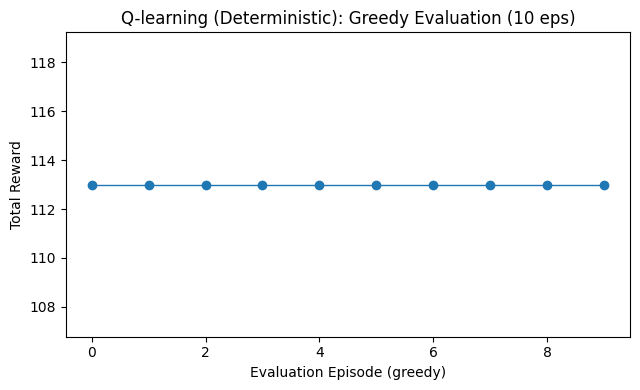

```
Stochastic (p=0.9) — Greedy showcase (episode 1):
[.] [A] [.] [.] [.] [P]
[.] [.] [#] [#] [.] [.]
[.] [.] [.] [#] [.] [.]
[.] [.] [.] [#] [.] [.]
[.] [#] [#] [.] [.] [.]
[.] [.] [.] [.] [.] [D]
pos=(0,1) carrying=False
[.] [.] [A] [.] [.] [P]
[.] [.] [#] [#] [.] [.]
[.] [.] [.] [#] [.] [.]
[.] [.] [.] [#] [.] [.]
[.] [#] [#] [.] [.] [.]
[.] [.] [.] [.] [.] [D]
pos=(0,2) carrying=False
[.] [.] [.] [A] [.] [P]
[.] [.] [#] [#] [.] [.]
[.] [.] [.] [#] [.] [.]
[.] [.] [.] [#] [.] [.]
[.] [#] [#] [.] [.] [.]
[.] [.] [.] [.] [.] [D]
pos=(0,3) carrying=False
[.] [.] [.] [.] [A] [P]
[.] [.] [#] [#] [.] [.]
[.] [.] [.] [#] [.] [.]
[.] [.] [.] [#] [.] [.]
[.] [#] [#] [.] [.] [.]
[.] [.] [.] [.] [.] [D]
pos=(0,4) carrying=False
[.] [.] [.] [.] [.] [A]
[.] [.] [#] [#] [.] [.]
[.] [.] [.] [#] [.] [.]
[.] [.] [.] [#] [.] [.]
[.] [#] [#] [.] [.] [.]
[.] [.] [.] [.] [.] [D]
pos=(0,5) carrying=False
[.] [.] [.] [.] [.] [a]
[.] [.] [#] [#] [.] [.]
[.] [.] [.] [#] [.] [.]
[.] [.] [.] [#] [.] [.]
```

[output cut: 38 more lines]

```
[.] [.] [.] [.] [.] [P]
[.] [.] [#] [#] [.] [.]
[.] [.] [.] [#] [.] [.]
[.] [.] [.] [#] [.] [.]
[.] [#] [#] [.] [.] [.]
[.] [.] [.] [.] [.] [a]
pos=(5,5) carrying=True
[.] [.] [.] [.] [.] [P]
[.] [.] [#] [#] [.] [.]
[.] [.] [.] [#] [.] [.]
[.] [.] [.] [#] [.] [.]
[.] [#] [#] [.] [.] [.]
[.] [.] [.] [.] [.] [A]
pos=(5,5) carrying=False
[Q-learning Greedy] Stochastic (p=0.9): mean=112.00, std=0.89, successes=10/10
```

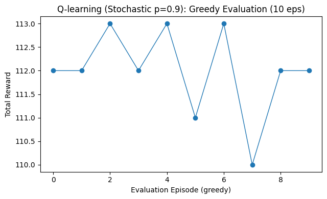

```
Saved plots: plots/det_qlearn_eval10.png, plots/sto_qlearn_eval10.png
```

```python
# Deterministic
det_returns, det_successes = evaluate_greedy(
    det_env, Q_det, episodes=10, max_steps=200, seed=1227,
    render_one=True, render_caption="Deterministic — Greedy showcase (episode 1):"
)
det_mean, det_std = float(np.mean(det_returns)), float(np.std(det_returns))
print(f"[Q-learning Greedy] Deterministic: mean={det_mean:.2f}, std={det_std:.2f}, "
      f"successes={det_successes}/10")

plot_eval_returns(det_returns,
    "Q-learning (Deterministic): Greedy Evaluation (10 eps)",
    outpath="plots/det_qlearn_eval10.png")

# Stochastic
sto_returns, sto_successes = evaluate_greedy(
    sto_env, Q_sto, episodes=10, max_steps=200, seed=1227,
    render_one=True, render_caption="Stochastic (p=0.9) — Greedy showcase (episode 1):"
)
sto_mean, sto_std = float(np.mean(sto_returns)), float(np.std(sto_returns))
print(f"[Q-learning Greedy] Stochastic (p=0.9): mean={sto_mean:.2f}, std={sto_std:.2f}, "
      f"successes={sto_successes}/10")

plot_eval_returns(sto_returns,
    "Q-learning (Stochastic p=0.9): Greedy Evaluation (10 eps)",
    outpath="plots/sto_qlearn_eval10.png")

print("Saved plots: plots/det_qlearn_eval10.png, plots/sto_qlearn_eval10.png")
```

# **6. Q-learning Hyperparameter Study**

I tune two Q-learning hyperparameters `gamma` and `epsilon_decay` each 3 values, and for each setting, I train on both environments, save reward/epsilon plots, run a 10-episode greedy eval, and log a concise summary. Finally, I pick a recommended setting based on performance (with extra weight on the stochastic env for robustness).

**6.1 Tuning plan**

Fixed baseline: `episodes=2000`, `max_steps=200`, `alpha=0.10`, `epsilon_start=1.0`, `epsilon_min=0.05`.

Grids:

- `gamma ∈ {0.90, 0.95, 0.99}`
- `epsilon_decay ∈ {0.999, 0.995, 0.990}`
- For each pair (`gamma`, `epsilon_decay`), do the full Q-learning run on Deterministic and Stochastic envs and evaluate greedily (10 eps).
- Save artifacts/plots into per-setting folders like:
  - artifacts/tuning/qlearn_gamma0.95_ed0.995/{det.pkl, sto.pkl}
  - plots/tuning/qlearn_gamma0.95_ed0.995/{det_rewards.png, det_eps.png, sto_rewards.png, sto_eps.png, det_eval10.png, sto_eval10.png}
- Make a summary table with columns: `gamma, epsilon_decay, det_mean, det_std, sto_mean, sto_std`.
- Recommendation rule: pick the row with the highest `sto_mean` (robustness), break ties by `det_mean`, then by smaller `std`s.

**6.2 Sweep utilities**

This cell wraps training+plotting+evaluation for a given (`gamma`, `epsilon_decay`), saves outputs, and returns the metrics we need.

```python
import os, pickle
import numpy as np
import pandas as pd
import matplotlib.pyplot as plt

def ensure_dir(path):
    os.makedirs(path, exist_ok=True)

def plot_series(y, title, xlabel, ylabel, outpath):
    plt.figure(figsize=(6.5,4.0))
    plt.plot(y)
    plt.title(title)
    plt.xlabel(xlabel)
    plt.ylabel(ylabel)
    plt.tight_layout()
    ensure_dir(os.path.dirname(outpath))
    plt.savefig(outpath, dpi=300)
    plt.show()
    plt.close()

def evaluate_greedy(env, Q, episodes=10, max_steps=200, seed=1227):
    totals, successes = [], 0
    for ep in range(episodes):
        obs, _ = env.reset(seed=seed + ep)
        s = obs_to_index(obs, env.n_rows, env.n_cols)
        total, delivered = 0.0, False
        for t in range(max_steps):
            a = int(np.argmax(Q[s]))
            obs2, r, terminated, truncated, _ = env.step(a)
            s = obs_to_index(obs2, env.n_rows, env.n_cols)
            total += r
            if terminated or truncated:
                delivered = terminated
                break
        totals.append(total)
        successes += int(delivered)
    return totals, successes

def tail_avg(x, n=100):
    arr = np.array(x[-n:]) if len(x) >= n else np.array(x)
    return float(arr.mean()), float(arr.std())

def run_one_setting(det_env, sto_env, gamma, epsilon_decay,
                    episodes=2000, max_steps=200, alpha=0.10,
                    epsilon_start=1.0, epsilon_min=0.05, seed=1227):
    tag = f"qlearn_gamma{gamma}_ed{epsilon_decay}"
    art_dir = f"artifacts/tuning/{tag}"
    plt_dir = f"plots/tuning/{tag}"
    ensure_dir(art_dir); ensure_dir(plt_dir)

    # Deterministic training
    Q_det, det_rewards, det_eps = train_q_learning(
        det_env, episodes=episodes, max_steps=max_steps,
        alpha=alpha, gamma=gamma,
        epsilon_start=epsilon_start, epsilon_min=epsilon_min, epsilon_decay=epsilon_decay,
        seed=seed
    )
    with open(f"{art_dir}/det.pkl", "wb") as f: pickle.dump(Q_det, f)
    plot_series(det_rewards, f"Q-learning DET: Reward (γ={gamma}, ed={epsilon_decay})",
                "Episode", "Total Reward", f"{plt_dir}/det_rewards.png")
    plot_series(det_eps, f"Q-learning DET: Epsilon (γ={gamma}, ed={epsilon_decay})",
                "Episode", "Epsilon", f"{plt_dir}/det_eps.png")
    det_eval, det_succ = evaluate_greedy(det_env, Q_det, episodes=10, max_steps=max_steps, seed=seed)
    plot_series(det_eval, f"Q-learning DET: Greedy Eval (10 eps) — (γ={gamma}, ed={epsilon_decay})",
                "Eval Episode", "Total Reward", f"{plt_dir}/det_eval10.png")
    det_mean, det_std = float(np.mean(det_eval)), float(np.std(det_eval))

    # Stochastic training
    Q_sto, sto_rewards, sto_eps = train_q_learning(
        sto_env, episodes=episodes, max_steps=max_steps,
        alpha=alpha, gamma=gamma,
        epsilon_start=epsilon_start, epsilon_min=epsilon_min, epsilon_decay=epsilon_decay,
        seed=seed
    )
    with open(f"{art_dir}/sto.pkl", "wb") as f: pickle.dump(Q_sto, f)
    plot_series(sto_rewards, f"Q-learning STO p=0.9: Reward (γ={gamma}, ed={epsilon_decay})",
                "Episode", "Total Reward", f"{plt_dir}/sto_rewards.png")
    plot_series(sto_eps, f"Q-learning STO p=0.9: Epsilon (γ={gamma}, ed={epsilon_decay})",
                "Episode", "Epsilon", f"{plt_dir}/sto_eps.png")
    sto_eval, sto_succ = evaluate_greedy(sto_env, Q_sto, episodes=10, max_steps=max_steps, seed=seed)
    plot_series(sto_eval, f"Q-learning STO p=0.9: Greedy Eval (10 eps) — (γ={gamma}, ed={epsilon_decay})",
                "Eval Episode", "Total Reward", f"{plt_dir}/sto_eval10.png")
    sto_mean, sto_std = float(np.mean(sto_eval)), float(np.std(sto_eval))

    # Return row for summary
    return {
        "gamma": gamma,
        "epsilon_decay": epsilon_decay,
        "det_mean": det_mean, "det_std": det_std, "det_successes": det_succ,
        "sto_mean": sto_mean, "sto_std": sto_std, "sto_successes": sto_succ,
        "art_dir": art_dir, "plt_dir": plt_dir
    }
```

**6.3 Run the grid, save a summary CSV, and print the recommendation**

This cell iterates over the (`gamma`, `epsilon_decay`) grid, runs the full pipeline per setting, collects metrics, writes a CSV, and prints the recommended config.

```
== Tuning run: gamma=0.9, epsilon_decay=0.999 ==
```

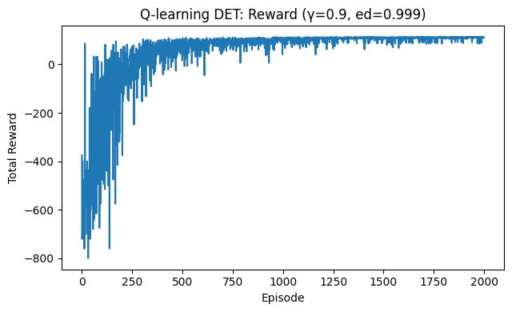

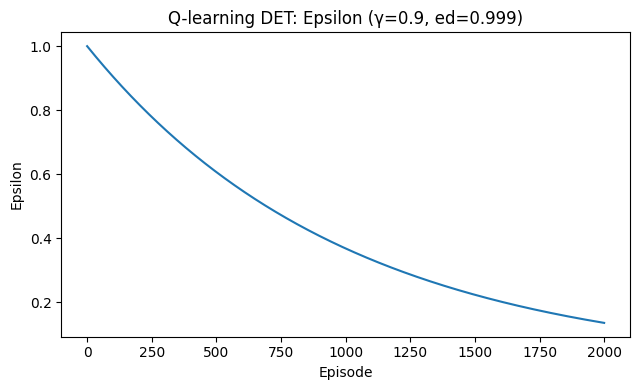

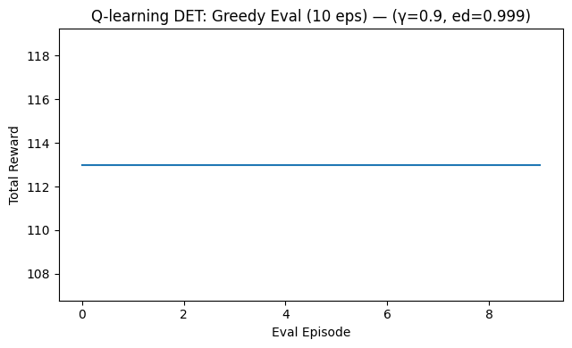

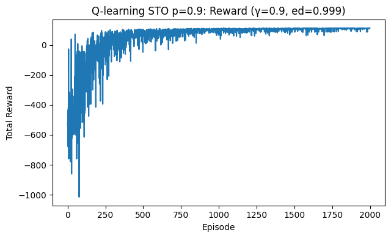

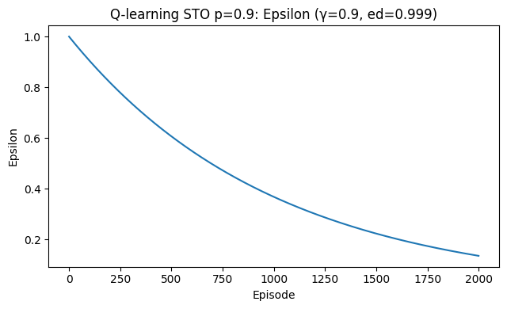

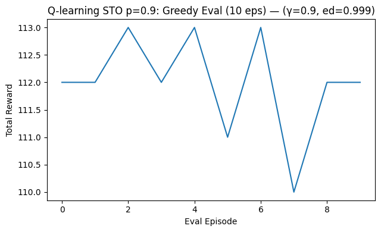

```
== Tuning run: gamma=0.9, epsilon_decay=0.995 ==
```

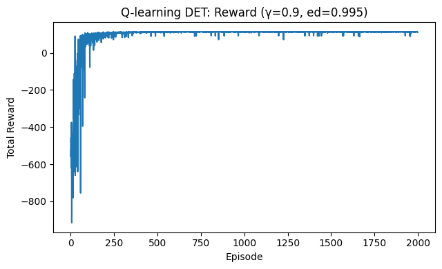

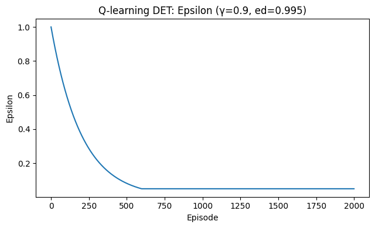

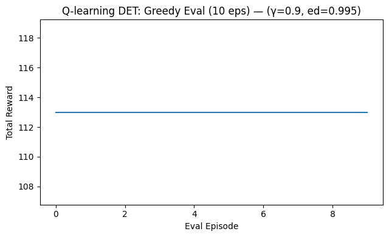

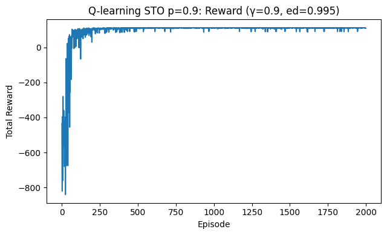

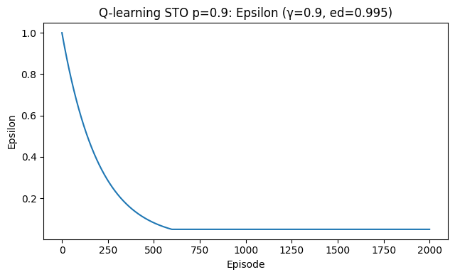

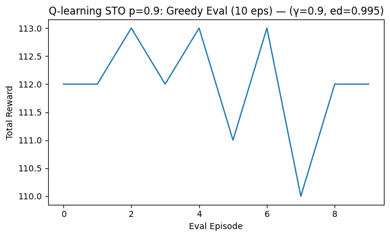

```
== Tuning run: gamma=0.9, epsilon_decay=0.99 ==
```

[42 more figures not shown]

Q-learning hyperparameter study — summary

|  | gamma | epsilon_decay | det_mean | det_std | det_successes | sto_mean | sto_std | sto_successes | art_dir | plt_dir |
| --- | --- | --- | --- | --- | --- | --- | --- | --- | --- | --- |
| 0 | 0.900000 | 0.999000 | 113.000000 | 0.000000 | 10 | 112.000000 | 0.894427 | 10 | artifacts/tuning/qlearn_gamma0.9_ed0.999 | plots/tuning/qlearn_gamma0.9_ed0.999 |
| 1 | 0.900000 | 0.995000 | 113.000000 | 0.000000 | 10 | 112.000000 | 0.894427 | 10 | artifacts/tuning/qlearn_gamma0.9_ed0.995 | plots/tuning/qlearn_gamma0.9_ed0.995 |
| 2 | 0.900000 | 0.990000 | 113.000000 | 0.000000 | 10 | 112.000000 | 0.894427 | 10 | artifacts/tuning/qlearn_gamma0.9_ed0.99 | plots/tuning/qlearn_gamma0.9_ed0.99 |
| 3 | 0.950000 | 0.999000 | 113.000000 | 0.000000 | 10 | 112.000000 | 0.894427 | 10 | artifacts/tuning/qlearn_gamma0.95_ed0.999 | plots/tuning/qlearn_gamma0.95_ed0.999 |
| 4 | 0.950000 | 0.995000 | 113.000000 | 0.000000 | 10 | 112.000000 | 0.894427 | 10 | artifacts/tuning/qlearn_gamma0.95_ed0.995 | plots/tuning/qlearn_gamma0.95_ed0.995 |
| 5 | 0.950000 | 0.990000 | 113.000000 | 0.000000 | 10 | 112.000000 | 0.894427 | 10 | artifacts/tuning/qlearn_gamma0.95_ed0.99 | plots/tuning/qlearn_gamma0.95_ed0.99 |
| 6 | 0.990000 | 0.999000 | 113.000000 | 0.000000 | 10 | 112.000000 | 0.894427 | 10 | artifacts/tuning/qlearn_gamma0.99_ed0.999 | plots/tuning/qlearn_gamma0.99_ed0.999 |
| 7 | 0.990000 | 0.995000 | 113.000000 | 0.000000 | 10 | 112.000000 | 0.894427 | 10 | artifacts/tuning/qlearn_gamma0.99_ed0.995 | plots/tuning/qlearn_gamma0.99_ed0.995 |
| 8 | 0.990000 | 0.990000 | 113.000000 | 0.000000 | 10 | 112.000000 | 0.894427 | 10 | artifacts/tuning/qlearn_gamma0.99_ed0.99 | plots/tuning/qlearn_gamma0.99_ed0.99 |

```
Recommended Q-learning settings:
  gamma=0.9, epsilon_decay=0.999
  Det: mean=113.00 (std=0.00), successes=10/10
  Sto: mean=112.00 (std=0.89), successes=10/10
  Artifacts dir: artifacts/tuning/qlearn_gamma0.9_ed0.999
  Plots dir: plots/tuning/qlearn_gamma0.9_ed0.999
  Full summary CSV: artifacts/tuning/qlearn_summary.csv
```

```python
# Reuse envs from earlier sections (same cfg)
cfg = WarehouseConfig()
det_env = WarehouseDeterministicEnv(cfg)
sto_env = WarehouseStochasticEnv(cfg, move_success_p=0.9)

gamma_grid = [0.90, 0.95, 0.99]
ed_grid    = [0.999, 0.995, 0.990]

rows = []
for g in gamma_grid:
    for ed in ed_grid:
        print(f"== Tuning run: gamma={g}, epsilon_decay={ed} ==")
        row = run_one_setting(det_env, sto_env, gamma=g, epsilon_decay=ed,
                              episodes=2000, max_steps=200, alpha=0.10,
                              epsilon_start=1.0, epsilon_min=0.05, seed=1227)
        rows.append(row)

summary = pd.DataFrame(rows)
summary_path = "artifacts/tuning/qlearn_summary.csv"
ensure_dir(os.path.dirname(summary_path))
summary.to_csv(summary_path, index=False)
display(summary.style.set_caption("Q-learning hyperparameter study — summary"))

# Recommendation: maximize sto_mean (robustness), tie-break by det_mean, then lower stds
summary_sorted = summary.sort_values(
    by=["sto_mean", "det_mean", "sto_std", "det_std"],
    ascending=[False, False, True, True]
).reset_index(drop=True)

best = summary_sorted.iloc[0].to_dict()
print("\nRecommended Q-learning settings:")
print(f"  gamma={best['gamma']}, epsilon_decay={best['epsilon_decay']}")
print(f"  Det: mean={best['det_mean']:.2f} (std={best['det_std']:.2f}), "
      f"successes={int(best['det_successes'])}/10")
print(f"  Sto: mean={best['sto_mean']:.2f} (std={best['sto_std']:.2f}), "
      f"successes={int(best['sto_successes'])}/10")
print(f"  Artifacts dir: {best['art_dir']}")
print(f"  Plots dir: {best['plt_dir']}")
print(f"  Full summary CSV: {summary_path}")
```

# **7. SARSA (Implementation & Training)**

We implement **SARSA** (on-policy TD control), then train and evaluate it on both environments using the **same baseline hyperparameters** as Q-learning (no tuning). We’ll

- (a) log reward and epsilon per episode,
- (b) show plots inline and also save them,
- (c) save trained tables to disk,
- (d) run 10-episode greedy evaluations with one rendered showcase, and
- (e) print concise **Q-table snapshots** (trained & untrained) for each environment.

**7.1 SARSA method**

- SARSA updates with the action actually taken next, (not the max) over next actions: $$ Q(s, a) \leftarrow Q(s, a) + \alpha \left( r + \gamma \cdot Q(s', a') - Q(s, a) \right) $$
- Exploration is still ε-greedy; therefore SARSA learns the value of the ε-greedy policy, which can be more conservative under stochastic transitions (e.g., with slips).

**7.2 SARSA training helper**

```python
import numpy as np
import matplotlib.pyplot as plt
import os, pickle

# Small plotting helper that both SHOWS inline and SAVES to file.
def plot_series_showsave(y, title, xlabel, ylabel, outpath):
    plt.figure(figsize=(6.5,4.0))
    plt.plot(y)
    plt.title(title)
    plt.xlabel(xlabel)
    plt.ylabel(ylabel)
    plt.tight_layout()
    os.makedirs(os.path.dirname(outpath), exist_ok=True)
    plt.savefig(outpath, dpi=300)
    plt.show()
    plt.close()

def train_sarsa(
    env,
    episodes=2000,
    max_steps=200,
    alpha=0.10,
    gamma=0.99,
    epsilon_start=1.0,
    epsilon_min=0.05,
    epsilon_decay=0.995,
    seed=1227,
):
    """
    Train tabular SARSA on the given env using ε-greedy exploration.
    Returns:
        Q, rewards_hist, eps_hist
    """
    # reuse init/epsilon_greedy from earlier sections
    Q = init_q_table(env)
    rewards_hist, eps_hist = [], []
    epsilon = float(epsilon_start)

    for ep in range(episodes):
        obs, _ = env.reset(seed=seed)
        s = obs_to_index(obs, env.n_rows, env.n_cols)
        a = epsilon_greedy(Q, s, epsilon)

        done = False
        total = 0.0

        for t in range(max_steps):
            obs2, r, terminated, truncated, _ = env.step(a)
            s2 = obs_to_index(obs2, env.n_rows, env.n_cols)
            done = terminated or truncated

            # choose next action on-policy
            a2 = None if done else epsilon_greedy(Q, s2, epsilon)

            # SARSA target uses Q[s', a']
            td_target = r if done else (r + gamma * Q[s2, a2])
            td_error  = td_target - Q[s, a]
            Q[s, a]  += alpha * td_error

            s, a = s2, (a2 if not done else a2)
            total += r
            if done:
                break

        rewards_hist.append(total)
        eps_hist.append(epsilon)
        epsilon = max(epsilon_min, epsilon * epsilon_decay)

    return Q, rewards_hist, eps_hist
```

**7.3 Train SARSA on both environments, show & save plots, save artifacts**

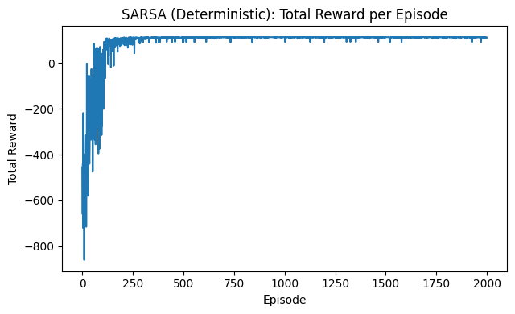

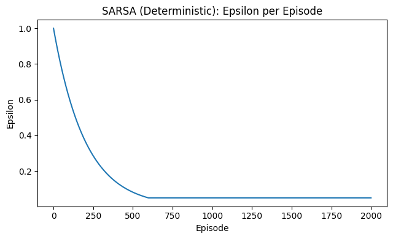

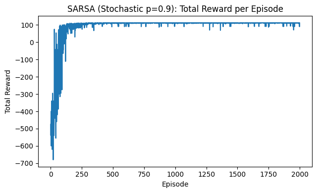

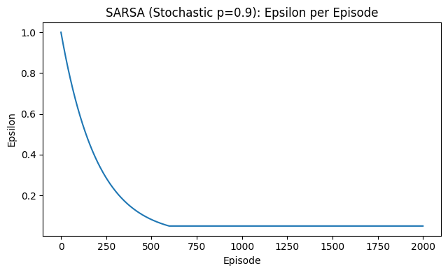

```python
# Ensure envs exist (reuse from earlier sections)
cfg = WarehouseConfig()
det_env = WarehouseDeterministicEnv(cfg)
sto_env = WarehouseStochasticEnv(cfg, move_success_p=0.9)

os.makedirs("artifacts", exist_ok=True)
os.makedirs("plots", exist_ok=True)

# Save untrained tables (traceability)
with open("artifacts/sarsa_det_untrained.pkl", "wb") as f:
    pickle.dump(init_q_table(det_env), f)
with open("artifacts/sarsa_sto_untrained.pkl", "wb") as f:
    pickle.dump(init_q_table(sto_env), f)

# Train with the same baseline settings used for Q-learning
SARSA_EPISODES = 2000
SARSA_STEPS    = 200
ALPHA, GAMMA   = 0.10, 0.99
EPS0, EPSMIN, EDS = 1.0, 0.05, 0.995

Qd_sarsa, det_rewards_sarsa, det_eps_sarsa = train_sarsa(
    det_env, episodes=SARSA_EPISODES, max_steps=SARSA_STEPS,
    alpha=ALPHA, gamma=GAMMA, epsilon_start=EPS0, epsilon_min=EPSMIN, epsilon_decay=EDS, seed=1227
)
Qs_sarsa, sto_rewards_sarsa, sto_eps_sarsa = train_sarsa(
    sto_env, episodes=SARSA_EPISODES, max_steps=SARSA_STEPS,
    alpha=ALPHA, gamma=GAMMA, epsilon_start=EPS0, epsilon_min=EPSMIN, epsilon_decay=EDS, seed=1227
)

# Save trained SARSA tables
with open("artifacts/sarsa_det.pkl", "wb") as f:
    pickle.dump(Qd_sarsa, f)
with open("artifacts/sarsa_sto.pkl", "wb") as f:
    pickle.dump(Qs_sarsa, f)

# Show + Save plots
plot_series_showsave(det_rewards_sarsa, "SARSA (Deterministic): Total Reward per Episode",
                     "Episode", "Total Reward", "plots/det_sarsa_rewards.png")
plot_series_showsave(det_eps_sarsa, "SARSA (Deterministic): Epsilon per Episode",
                     "Episode", "Epsilon", "plots/det_sarsa_epsilon.png")

plot_series_showsave(sto_rewards_sarsa, "SARSA (Stochastic p=0.9): Total Reward per Episode",
                     "Episode", "Total Reward", "plots/sto_sarsa_rewards.png")
plot_series_showsave(sto_eps_sarsa, "SARSA (Stochastic p=0.9): Epsilon per Episode",
                     "Episode", "Epsilon", "plots/sto_sarsa_epsilon.png")
```

**7.4 Greedy evaluation (10 episodes) + one rendered showcase per env**

```
SARSA — Deterministic: Greedy showcase (episode 1)
[.] [A] [.] [.] [.] [P]
[.] [.] [#] [#] [.] [.]
[.] [.] [.] [#] [.] [.]
[.] [.] [.] [#] [.] [.]
[.] [#] [#] [.] [.] [.]
[.] [.] [.] [.] [.] [D]
pos=(0,1) carrying=False
[.] [.] [A] [.] [.] [P]
[.] [.] [#] [#] [.] [.]
[.] [.] [.] [#] [.] [.]
[.] [.] [.] [#] [.] [.]
[.] [#] [#] [.] [.] [.]
[.] [.] [.] [.] [.] [D]
pos=(0,2) carrying=False
[.] [.] [.] [A] [.] [P]
[.] [.] [#] [#] [.] [.]
[.] [.] [.] [#] [.] [.]
[.] [.] [.] [#] [.] [.]
[.] [#] [#] [.] [.] [.]
[.] [.] [.] [.] [.] [D]
pos=(0,3) carrying=False
[.] [.] [.] [.] [A] [P]
[.] [.] [#] [#] [.] [.]
[.] [.] [.] [#] [.] [.]
[.] [.] [.] [#] [.] [.]
[.] [#] [#] [.] [.] [.]
[.] [.] [.] [.] [.] [D]
pos=(0,4) carrying=False
[.] [.] [.] [.] [.] [A]
[.] [.] [#] [#] [.] [.]
[.] [.] [.] [#] [.] [.]
[.] [.] [.] [#] [.] [.]
[.] [#] [#] [.] [.] [.]
[.] [.] [.] [.] [.] [D]
pos=(0,5) carrying=False
[.] [.] [.] [.] [.] [a]
[.] [.] [#] [#] [.] [.]
[.] [.] [.] [#] [.] [.]
[.] [.] [.] [#] [.] [.]
```

[output cut: 31 more lines]

```
[.] [.] [.] [.] [.] [P]
[.] [.] [#] [#] [.] [.]
[.] [.] [.] [#] [.] [.]
[.] [.] [.] [#] [.] [.]
[.] [#] [#] [.] [.] [.]
[.] [.] [.] [.] [.] [a]
pos=(5,5) carrying=True
[.] [.] [.] [.] [.] [P]
[.] [.] [#] [#] [.] [.]
[.] [.] [.] [#] [.] [.]
[.] [.] [.] [#] [.] [.]
[.] [#] [#] [.] [.] [.]
[.] [.] [.] [.] [.] [A]
pos=(5,5) carrying=False
[SARSA Greedy] Deterministic: mean=113.00, std=0.00, successes=10/10
```

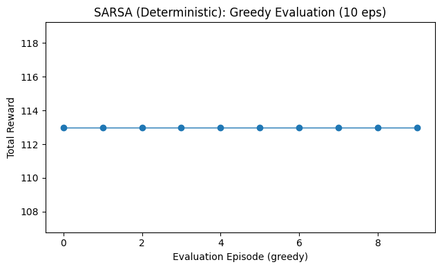

```
SARSA — Stochastic (p=0.9): Greedy showcase (episode 1)
[.] [A] [.] [.] [.] [P]
[.] [.] [#] [#] [.] [.]
[.] [.] [.] [#] [.] [.]
[.] [.] [.] [#] [.] [.]
[.] [#] [#] [.] [.] [.]
[.] [.] [.] [.] [.] [D]
pos=(0,1) carrying=False
[.] [.] [A] [.] [.] [P]
[.] [.] [#] [#] [.] [.]
[.] [.] [.] [#] [.] [.]
[.] [.] [.] [#] [.] [.]
[.] [#] [#] [.] [.] [.]
[.] [.] [.] [.] [.] [D]
pos=(0,2) carrying=False
[.] [.] [.] [A] [.] [P]
[.] [.] [#] [#] [.] [.]
[.] [.] [.] [#] [.] [.]
[.] [.] [.] [#] [.] [.]
[.] [#] [#] [.] [.] [.]
[.] [.] [.] [.] [.] [D]
pos=(0,3) carrying=False
[.] [.] [.] [.] [A] [P]
[.] [.] [#] [#] [.] [.]
[.] [.] [.] [#] [.] [.]
[.] [.] [.] [#] [.] [.]
[.] [#] [#] [.] [.] [.]
[.] [.] [.] [.] [.] [D]
pos=(0,4) carrying=False
[.] [.] [.] [.] [.] [A]
[.] [.] [#] [#] [.] [.]
[.] [.] [.] [#] [.] [.]
[.] [.] [.] [#] [.] [.]
[.] [#] [#] [.] [.] [.]
[.] [.] [.] [.] [.] [D]
pos=(0,5) carrying=False
[.] [.] [.] [.] [.] [a]
[.] [.] [#] [#] [.] [.]
[.] [.] [.] [#] [.] [.]
[.] [.] [.] [#] [.] [.]
```

[output cut: 38 more lines]

```
[.] [.] [.] [.] [.] [P]
[.] [.] [#] [#] [.] [.]
[.] [.] [.] [#] [.] [.]
[.] [.] [.] [#] [.] [.]
[.] [#] [#] [.] [.] [.]
[.] [.] [.] [.] [.] [a]
pos=(5,5) carrying=True
[.] [.] [.] [.] [.] [P]
[.] [.] [#] [#] [.] [.]
[.] [.] [.] [#] [.] [.]
[.] [.] [.] [#] [.] [.]
[.] [#] [#] [.] [.] [.]
[.] [.] [.] [.] [.] [A]
pos=(5,5) carrying=False
[SARSA Greedy] Stochastic: mean=112.00, std=0.89, successes=10/10
```

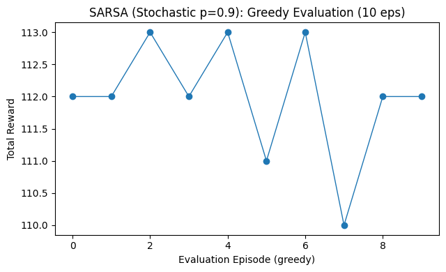

```python
import numpy as np
import matplotlib.pyplot as plt

def evaluate_greedy(env, Q, episodes=10, max_steps=200, seed=1227, render_one=False, caption=""):
    totals, successes = [], 0
    for ep in range(episodes):
        obs, _ = env.reset(seed=seed + ep)
        s = obs_to_index(obs, env.n_rows, env.n_cols)
        total, delivered = 0.0, False
        if render_one and ep == 0 and caption:
            print(caption)
        for t in range(max_steps):
            a = int(np.argmax(Q[s]))
            obs2, r, terminated, truncated, _ = env.step(a)
            s = obs_to_index(obs2, env.n_rows, env.n_cols)
            total += r
            if render_one and ep == 0:
                env.render()
            if terminated or truncated:
                delivered = terminated
                break
        totals.append(total)
        successes += int(delivered)
    return totals, successes

def plot_eval_returns_showsave(returns, title, outpath):
    plt.figure(figsize=(6.5,4.0))
    plt.plot(returns, marker="o", linewidth=1)
    plt.title(title)
    plt.xlabel("Evaluation Episode (greedy)")
    plt.ylabel("Total Reward")
    plt.tight_layout()
    plt.show()
    plt.savefig(outpath, dpi=300)
    plt.close()

# Deterministic
det_eval_sarsa, det_succ_sarsa = evaluate_greedy(
    det_env, Qd_sarsa, episodes=10, max_steps=200, seed=1227,
    render_one=True, caption="SARSA — Deterministic: Greedy showcase (episode 1)"
)
print(f"[SARSA Greedy] Deterministic: mean={np.mean(det_eval_sarsa):.2f}, "
      f"std={np.std(det_eval_sarsa):.2f}, successes={det_succ_sarsa}/10")
plot_eval_returns_showsave(det_eval_sarsa,
    "SARSA (Deterministic): Greedy Evaluation (10 eps)",
    "plots/det_sarsa_eval10.png")

# Stochastic
sto_eval_sarsa, sto_succ_sarsa = evaluate_greedy(
    sto_env, Qs_sarsa, episodes=10, max_steps=200, seed=1227,
    render_one=True, caption="SARSA — Stochastic (p=0.9): Greedy showcase (episode 1)"
)
print(f"[SARSA Greedy] Stochastic: mean={np.mean(sto_eval_sarsa):.2f}, "
      f"std={np.std(sto_eval_sarsa):.2f}, successes={sto_succ_sarsa}/10")
plot_eval_returns_showsave(sto_eval_sarsa,
    "SARSA (Stochastic p=0.9): Greedy Evaluation (10 eps)",
    "plots/sto_sarsa_eval10.png")
```

**7.5 Q-table snapshots (det/stoch × untrained/trained)**

```python
import pandas as pd
from IPython.display import display

def load_q(path):
    with open(path, "rb") as f:
        return pickle.load(f)

def show_table(name, Q, head_k=8):
    print(f"{name}: shape={Q.shape}, min={Q.min():.3f}, max={Q.max():.3f}, mean={Q.mean():.3f}")
    df = pd.DataFrame(Q[:head_k], columns=["UP","DOWN","LEFT","RIGHT","PICK","DROP"])
    display(df.style.set_caption(f"{name} — first {head_k} rows"))

Q_det_un_sarsa  = load_q("artifacts/sarsa_det_untrained.pkl")
Q_det_tr_sarsa  = load_q("artifacts/sarsa_det.pkl")
Q_sto_un_sarsa  = load_q("artifacts/sarsa_sto_untrained.pkl")
Q_sto_tr_sarsa  = load_q("artifacts/sarsa_sto.pkl")

show_table("SARSA — Deterministic (Untrained)", Q_det_un_sarsa)
show_table("SARSA — Deterministic (Trained)",   Q_det_tr_sarsa)
show_table("SARSA — Stochastic p=0.9 (Untrained)", Q_sto_un_sarsa)
show_table("SARSA — Stochastic p=0.9 (Trained)",   Q_sto_tr_sarsa)
```

```
SARSA — Deterministic (Untrained): shape=(72, 6), min=0.000, max=0.000, mean=0.000
```

SARSA — Deterministic (Untrained) — first 8 rows

|  | UP | DOWN | LEFT | RIGHT | PICK | DROP |
| --- | --- | --- | --- | --- | --- | --- |
| 0 | 0.000000 | 0.000000 | 0.000000 | 0.000000 | 0.000000 | 0.000000 |
| 1 | 0.000000 | 0.000000 | 0.000000 | 0.000000 | 0.000000 | 0.000000 |
| 2 | 0.000000 | 0.000000 | 0.000000 | 0.000000 | 0.000000 | 0.000000 |
| 3 | 0.000000 | 0.000000 | 0.000000 | 0.000000 | 0.000000 | 0.000000 |
| 4 | 0.000000 | 0.000000 | 0.000000 | 0.000000 | 0.000000 | 0.000000 |
| 5 | 0.000000 | 0.000000 | 0.000000 | 0.000000 | 0.000000 | 0.000000 |
| 6 | 0.000000 | 0.000000 | 0.000000 | 0.000000 | 0.000000 | 0.000000 |
| 7 | 0.000000 | 0.000000 | 0.000000 | 0.000000 | 0.000000 | 0.000000 |

```
SARSA — Deterministic (Trained): shape=(72, 6), min=-40.456, max=109.456, mean=8.954
```

SARSA — Deterministic (Trained) — first 8 rows

|  | UP | DOWN | LEFT | RIGHT | PICK | DROP |
| --- | --- | --- | --- | --- | --- | --- |
| 0 | 68.333679 | 20.328031 | 57.541770 | 83.294026 | 53.740325 | 60.634317 |
| 1 | 63.698488 | 24.816145 | 56.426600 | 93.833008 | 75.332703 | 78.376305 |
| 2 | 67.184389 | 41.306429 | 64.429657 | 98.509697 | 75.079270 | 72.074367 |
| 3 | 85.511535 | 49.891221 | 59.599628 | 97.694027 | 72.018689 | 85.417902 |
| 4 | 76.151973 | 48.866468 | 68.452480 | 106.035345 | 90.300544 | 82.568603 |
| 5 | 91.684478 | 65.770390 | 81.000707 | 88.854013 | 109.455637 | 78.509508 |
| 6 | 56.668568 | -18.463822 | -12.008307 | -18.866693 | -18.531871 | -18.237309 |
| 7 | 65.507926 | -17.770109 | -17.416840 | -35.153955 | -20.536100 | -18.751398 |

```
SARSA — Stochastic p=0.9 (Untrained): shape=(72, 6), min=0.000, max=0.000, mean=0.000
```

SARSA — Stochastic p=0.9 (Untrained) — first 8 rows

|  | UP | DOWN | LEFT | RIGHT | PICK | DROP |
| --- | --- | --- | --- | --- | --- | --- |
| 0 | 0.000000 | 0.000000 | 0.000000 | 0.000000 | 0.000000 | 0.000000 |
| 1 | 0.000000 | 0.000000 | 0.000000 | 0.000000 | 0.000000 | 0.000000 |
| 2 | 0.000000 | 0.000000 | 0.000000 | 0.000000 | 0.000000 | 0.000000 |
| 3 | 0.000000 | 0.000000 | 0.000000 | 0.000000 | 0.000000 | 0.000000 |
| 4 | 0.000000 | 0.000000 | 0.000000 | 0.000000 | 0.000000 | 0.000000 |
| 5 | 0.000000 | 0.000000 | 0.000000 | 0.000000 | 0.000000 | 0.000000 |
| 6 | 0.000000 | 0.000000 | 0.000000 | 0.000000 | 0.000000 | 0.000000 |
| 7 | 0.000000 | 0.000000 | 0.000000 | 0.000000 | 0.000000 | 0.000000 |

```
SARSA — Stochastic p=0.9 (Trained): shape=(72, 6), min=-35.671, max=108.130, mean=9.943
```

SARSA — Stochastic p=0.9 (Trained) — first 8 rows

|  | UP | DOWN | LEFT | RIGHT | PICK | DROP |
| --- | --- | --- | --- | --- | --- | --- |
| 0 | 51.563445 | 20.365820 | 59.889792 | 87.829363 | 54.344564 | 49.630504 |
| 1 | 67.364319 | 12.692879 | 55.825241 | 88.503782 | 74.056019 | 73.717879 |
| 2 | 79.619603 | 54.316902 | 50.949851 | 95.369901 | 77.935513 | 72.022359 |
| 3 | 75.704713 | 62.598198 | 74.888718 | 99.398005 | 71.337465 | 81.756057 |
| 4 | 82.052943 | 58.098226 | 79.104822 | 102.246703 | 76.832019 | 88.820190 |
| 5 | 86.881303 | 50.660702 | 83.588699 | 87.414696 | 108.130295 | 85.254312 |
| 6 | 57.530229 | -14.606508 | -14.512077 | -14.348931 | -13.875203 | -13.404437 |
| 7 | 50.051874 | -14.195705 | -14.213757 | -34.275759 | -15.223858 | -15.865322 |

# **8. Head-to-Head Comparisons (Q-learning vs SARSA)**

We compare Q-learning and SARSA on each environment. First, we overlay learning curves (total reward per episode) side-by-side. Then we run fresh greedy evaluations (10 eps) for both methods and show a tiny summary table (mean ± std, successes). Plots are shown inline and also saved.

**8.1 Learning-curve overlays**

This cell uses the reward histories already in memory from Sections 4 & 7.

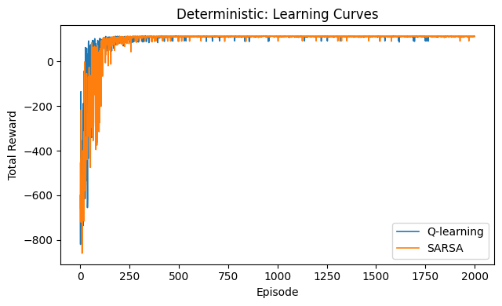

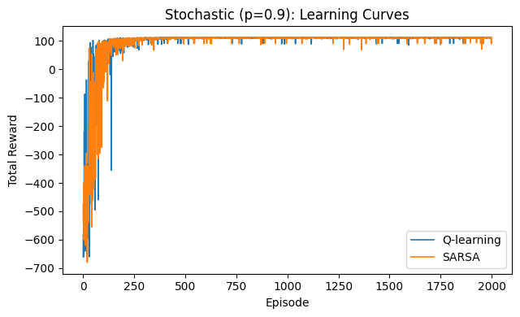

```python
import os
import matplotlib.pyplot as plt

os.makedirs("plots/compare", exist_ok=True)

def overlay_learning_curves(y1, y2, title, label1, label2, outpath):
    if y1 is None or y2 is None:
        print(f"[WARN] Missing histories for: {title} — rerun training cells to populate.")
        return
    plt.figure(figsize=(6.5,4))
    plt.plot(y1, label=label1, linewidth=1.2)
    plt.plot(y2, label=label2, linewidth=1.2)
    plt.title(title)
    plt.xlabel("Episode")
    plt.ylabel("Total Reward")
    plt.legend()
    plt.tight_layout()
    plt.show()
    plt.savefig(outpath, dpi=300)
    plt.close()

# Expect these from earlier sections:
# Q-learning: det_rewards, sto_rewards
# SARSA:     det_rewards_sarsa, sto_rewards_sarsa

overlay_learning_curves(
    'det_rewards' in globals() and det_rewards or None,
    'det_rewards_sarsa' in globals() and det_rewards_sarsa or None,
    "Deterministic: Learning Curves",
    "Q-learning", "SARSA",
    "plots/compare/det_q_vs_sarsa_rewards.png"
)

overlay_learning_curves(
    'sto_rewards' in globals() and sto_rewards or None,
    'sto_rewards_sarsa' in globals() and sto_rewards_sarsa or None,
    "Stochastic (p=0.9): Learning Curves",
    "Q-learning", "SARSA",
    "plots/compare/sto_q_vs_sarsa_rewards.png"
)
```

**8.2 Greedy evaluation comparison (10 eps) + summary table**

We reload trained tables (to be robust), run greedy evals for both methods on both envs, and plot & tabulate results.

Greedy evaluation (10 eps): mean ± std and successes

|  | env | method | mean | std | successes |
| --- | --- | --- | --- | --- | --- |
| 0 | Deterministic | Q-learning | 113.000000 | 0.000000 | 10 |
| 1 | Deterministic | SARSA | 113.000000 | 0.000000 | 10 |
| 2 | Stochastic p=0.9 | Q-learning | 112.000000 | 0.894427 | 10 |
| 3 | Stochastic p=0.9 | SARSA | 112.000000 | 0.894427 | 10 |

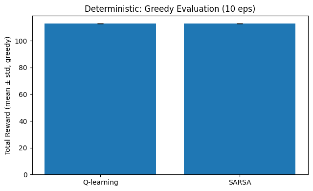

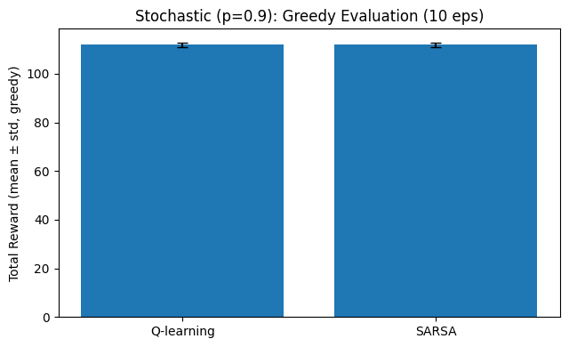

```
Saved comparison plots: plots/compare/det_q_vs_sarsa_rewards.png, plots/compare/sto_q_vs_sarsa_rewards.png, plots/compare/det_q_vs_sarsa_eval10.png, plots/compare/sto_q_vs_sarsa_eval10.png
```

```python
import os, pickle, numpy as np, pandas as pd
import matplotlib.pyplot as plt

def load_q(path):
    with open(path, "rb") as f:
        return pickle.load(f)

def evaluate_greedy(env, Q, episodes=10, max_steps=200, seed=1227):
    totals, successes = [], 0
    for ep in range(episodes):
        obs, _ = env.reset(seed=seed + ep)
        s = obs_to_index(obs, env.n_rows, env.n_cols)
        total, delivered = 0.0, False
        for t in range(max_steps):
            a = int(np.argmax(Q[s]))
            obs2, r, terminated, truncated, _ = env.step(a)
            s = obs_to_index(obs2, env.n_rows, env.n_cols)
            total += r
            if terminated or truncated:
                delivered = terminated
                break
        totals.append(total)
        successes += int(delivered)
    return np.array(totals), successes

def barplot_eval(vals_dict, title, outpath):
    plt.figure(figsize=(6.5,4))
    labels = list(vals_dict.keys())
    means  = [v.mean() for v in vals_dict.values()]
    stds   = [v.std(ddof=0) for v in vals_dict.values()]
    xs = range(len(labels))
    plt.bar(xs, means, yerr=stds, capsize=4)
    plt.xticks(xs, labels)
    plt.title(title)
    plt.ylabel("Total Reward (mean ± std, greedy)")
    plt.tight_layout()
    plt.show()
    plt.savefig(outpath, dpi=300)
    plt.close()

# Recreate envs
cfg = WarehouseConfig()
det_env = WarehouseDeterministicEnv(cfg)
sto_env = WarehouseStochasticEnv(cfg, move_success_p=0.9)

# Load trained tables
Q_det_q     = load_q("artifacts/qlearning_det.pkl")
Q_sto_q     = load_q("artifacts/qlearning_sto.pkl")
Q_det_sarsa = load_q("artifacts/sarsa_det.pkl")
Q_sto_sarsa = load_q("artifacts/sarsa_sto.pkl")

# Evaluate
det_q_vals, det_q_ok         = evaluate_greedy(det_env, Q_det_q, episodes=10)
det_sarsa_vals, det_sarsa_ok = evaluate_greedy(det_env, Q_det_sarsa, episodes=10)
sto_q_vals, sto_q_ok         = evaluate_greedy(sto_env, Q_sto_q, episodes=10)
sto_sarsa_vals, sto_sarsa_ok = evaluate_greedy(sto_env, Q_sto_sarsa, episodes=10)

# Summary table
summary = pd.DataFrame([
    {"env":"Deterministic", "method":"Q-learning", "mean":det_q_vals.mean(), "std":det_q_vals.std(ddof=0), "successes":det_q_ok},
    {"env":"Deterministic", "method":"SARSA",      "mean":det_sarsa_vals.mean(), "std":det_sarsa_vals.std(ddof=0), "successes":det_sarsa_ok},
    {"env":"Stochastic p=0.9", "method":"Q-learning", "mean":sto_q_vals.mean(), "std":sto_q_vals.std(ddof=0), "successes":sto_q_ok},
    {"env":"Stochastic p=0.9", "method":"SARSA",      "mean":sto_sarsa_vals.mean(), "std":sto_sarsa_vals.std(ddof=0), "successes":sto_sarsa_ok},
])
display(summary.style.set_caption("Greedy evaluation (10 eps): mean ± std and successes"))

# Bar plots
os.makedirs("plots/compare", exist_ok=True)
barplot_eval(
    {"Q-learning": det_q_vals, "SARSA": det_sarsa_vals},
    "Deterministic: Greedy Evaluation (10 eps)",
    "plots/compare/det_q_vs_sarsa_eval10.png"
)
barplot_eval(
    {"Q-learning": sto_q_vals, "SARSA": sto_sarsa_vals},
    "Stochastic (p=0.9): Greedy Evaluation (10 eps)",
    "plots/compare/sto_q_vs_sarsa_eval10.png"
)

print("Saved comparison plots:",
      "plots/compare/det_q_vs_sarsa_rewards.png,",
      "plots/compare/sto_q_vs_sarsa_rewards.png,",
      "plots/compare/det_q_vs_sarsa_eval10.png,",
      "plots/compare/sto_q_vs_sarsa_eval10.png")
```

# **9. Discussion & Takeaways**

- Both Q-learning and SARSA solved the task on the 6×6 grid. Learning curves quickly rose and stabilized; greedy evals hit 10/10 deliveries in both environments.
- In practice, both converged to the same greedy policy, so final returns matched (Deterministic ≈ 113, Stochastic p=0.9 ≈ 112).

**Q-learning vs SARSA (behavior).**

- Q-learning (off-policy, max-bootstrap) learned slightly faster early on; after ε decayed, curves overlapped.
- SARSA (on-policy) was similarly stable; in noisier setups it can be marginally more conservative, but here the gap was negligible.

**Effect of stochasticity.**

- With movement slip (p=0.9), final returns were a touch lower and variance slightly higher (rare slips/blocked moves).
- The learned routes still delivered reliably; both methods handled the mild stochasticity without special tuning.

**Hyperparameter recommendation (Q-learning).**

- From the sweep, a robust, simple choice is `γ = 0.90`, `ε_decay = 0.999`, with `α = 0.10`, `ε_start = 1.0`, `ε_min = 0.05`, `episodes = 2000`, `max_steps = 200`.
- Many nearby settings performed equivalently due to the problem’s simplicity; the above is reproducible and stable.

**When to pick which.**

- Prefer Q-learning as a default (fast, simple, strong baseline).
- Use SARSA when the acting policy’s exploration affects safety or when you want on-policy values under persistent ε (e.g., in riskier stochastic tasks).

# **References**